# Reconstruction Accuracy Does Not Imply Inferential Validity

Evaluation of imputation methods for missing wrist-worn accelerometry data

Robert Adongo

October 2026

Department of Mathematics and Statistics, University of ToledoResearch report · October 2026[Repository and aggregate results ↗](https://github.com/adongo123/Wearable_Accelerometry_Imputation)Reproducibility statement ↓

# Abstract

Missing wrist-worn accelerometry measurements are frequently reconstructed before downstream analysis, but lower reconstruction error does not necessarily imply valid regression inference. We compared linear interpolation, hierarchical time-of-day means, $k$-nearest neighbors (kNN), and random forest using recorded hourly NHANES 2011–2014 activity summaries as reference measurements. Artificial 1-, 3-, and 6-hour gaps were introduced into complete eight-hour windows selected from 3,635 participants across 20 masking replications. Performance was assessed using hourly and participant-level exposure errors and age- and sex-adjusted regression estimates from 200 simulated outcomes per replication (4,000 fits per method–gap combination). For six-hour gaps, random forest achieved the lowest hourly root mean squared error (RMSE; 446.53), but its mean activity coefficient was 0.5536 (true value 0.5) and nominal 95% confidence-interval coverage was 28.82%. kNN had a higher hourly RMSE (463.43), a mean coefficient of 0.5057, and 95.10% coverage. A Frisch–Waugh–Lovell projection characterized this coefficient distortion. Separate null-effect, outcome-aware multiple-imputation, and observed BMI analyses examined related but distinct settings. The reported tables are generated from archived research outputs, with explicit checks against saved manuscript results; the website does not rerun the original simulations.

**Keywords** Accelerometry · Missing data · Imputation · Measurement error · Regression inference · NHANES · Reproducibility

Research finding

Lower reconstruction error does not necessarily yield more reliable regression inference.

NHANES hourly accelerometry · Semi-synthetic evaluation · Archived-results validation

3,635

Participants in primary simulation

20

Masking replications

4,000

Outcome fits per configuration

16

Public aggregate verification checks

**Analysis provenance.** All primary results below are calculated from the original archived summaries. Scripts `70.R` and `72.R` generated the principal reconstruction and regression outputs, and `81.R` generated manuscript Tables 1 and 2. The site renders the results and checks their consistency without repeating model training or outcome simulations.

# Primary results

## Principal six-hour comparison

The six-hour missing-block design exhibits the largest divergence between reconstruction accuracy and inferential calibration. Results below combine the original reconstruction and regression summaries. Values are calculated at render time from those saved outputs.

```r
six_reconstruction <- recon[recon$gap_hours == 6L,
  c("gap_hours", "method", "mean_hourly_RMSE", "mean_exposure_RMSE")]
six_inference <- inference[inference$gap_hours == 6L,
  c("gap_hours", "method", "mean_beta", "bias", "coverage")]
six_joint <- merge(six_reconstruction, six_inference,
                   by = c("gap_hours", "method"), sort=FALSE)
stopifnot(nrow(six_joint)==4L, !anyDuplicated(six_joint$method))
six_joint <- six_joint[match(c("Random forest", "kNN (k = 5)",
       "Linear interpolation", "Time-of-day mean"), six_joint$method), ]
knitr::kable(data.frame(
  Method = six_joint$method,
  `Hourly RMSE` = sprintf("%.1f", six_joint$mean_hourly_RMSE),
  `Exposure RMSE` = sprintf("%.1f", six_joint$mean_exposure_RMSE),
  `Mean coefficient` = sprintf("%.4f", six_joint$mean_beta),
  `95% CI coverage` = sprintf("%.1f%%", 100*six_joint$coverage),
  check.names=FALSE
), caption="Six-hour gaps: linked results from the archived reconstruction and inference summaries. True simulated activity coefficient = 0.5.")
```

Six-hour gaps: linked results from the archived reconstruction and inference summaries. True simulated activity coefficient = 0.5.

| Method | Hourly RMSE | Exposure RMSE | Mean coefficient | 95% CI coverage |
| --- | --- | --- | --- | --- |
| Random forest | 446.5 | 223.5 | 0.5536 | 28.8% |
| kNN (k = 5) | 463.4 | 221.0 | 0.5057 | 95.1% |
| Linear interpolation | 466.4 | 240.7 | 0.4096 | 0.0% |
| Time-of-day mean | 487.1 | 233.1 | 0.5607 | 23.3% |

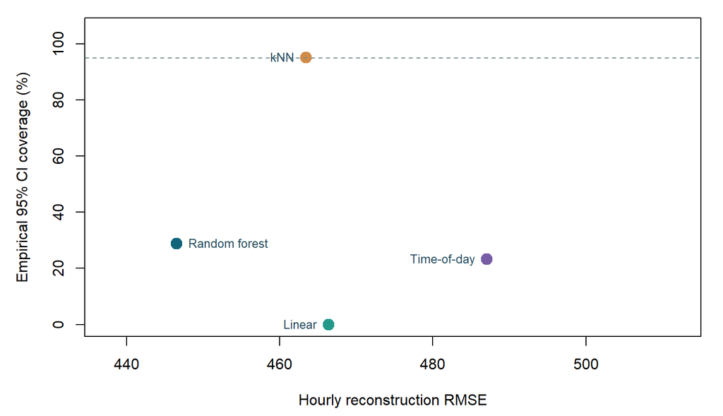

Six-hour missing blocks: hourly reconstruction error compared with regression confidence-interval coverage. The dashed line indicates nominal 95% coverage.

```r
cols <- c("#11647a", "#d08b47", "#22998b", "#775ca6")
par(mar=c(4.4,4.7,1.0,1.2))
plot(six_joint$mean_hourly_RMSE, 100*six_joint$coverage,
     pch=19, cex=1.7, col=cols,
     xlab="Hourly reconstruction RMSE", ylab="Empirical 95% CI coverage (%)",
     xlim=range(six_joint$mean_hourly_RMSE)+c(-9,25), ylim=c(0,105))
abline(h=95, col="#738b90", lty=2)
text(six_joint$mean_hourly_RMSE, 100*six_joint$coverage,
     labels=c("Random forest","kNN","Linear","Time-of-day"),
     pos=c(4,2,2,2), cex=.82, col="#244b5d", offset=.65)
```

**Interpretation.** Random forest minimized hourly RMSE in this setting, while kNN had much higher coverage of the known regression coefficient. This is a property of the evaluated design, not an across-dataset ranking of algorithms.

## Reconstruction accuracy

Reconstruction accuracy is assessed at two resolutions: the missing hourly measurements, and the participant-level mean over the full eight-hour window. These objectives are related but not identical, because hourly errors may accumulate or offset each other when values are averaged.

```r
method_order <- c(
  "Random forest", "kNN (k = 5)",
  "Linear interpolation", "Time-of-day mean"
)
recon <- recon[order(recon$gap_hours, match(recon$method, method_order)), ]

recon_display <- data.frame(
  `Gap (hours)` = recon$gap_hours,
  `Method` = recon$method,
  `Hourly RMSE` = sprintf("%.2f", recon$mean_hourly_RMSE),
  `Exposure RMSE` = sprintf("%.2f", recon$mean_exposure_RMSE),
  `Exposure bias` = sprintf("%.2f", recon$mean_exposure_Bias),
  check.names = FALSE
)
knitr::kable(
  recon_display, align = c("r", "l", "r", "r", "r"),
  caption = "Reconstruction performance averaged across 20 masking replications."
)
```

Reconstruction performance averaged across 20 masking replications.

| Gap (hours) | Method | Hourly RMSE | Exposure RMSE | Exposure bias |
| --- | --- | --- | --- | --- |
| 1 | Random forest | 341.11 | 42.64 | 0.51 |
| 1 | kNN (k = 5) | 373.02 | 46.63 | -1.07 |
| 1 | Linear interpolation | 376.13 | 47.02 | -1.56 |
| 1 | Time-of-day mean | 470.28 | 58.79 | -6.08 |
| 3 | Random forest | 384.63 | 101.71 | -26.99 |
| 3 | kNN (k = 5) | 407.17 | 106.17 | -17.31 |
| 3 | Linear interpolation | 421.75 | 119.27 | -9.28 |
| 3 | Time-of-day mean | 473.84 | 133.59 | -19.23 |
| 6 | Random forest | 446.53 | 223.46 | -109.78 |
| 6 | kNN (k = 5) | 463.43 | 220.96 | -81.50 |
| 6 | Linear interpolation | 466.42 | 240.75 | -46.06 |
| 6 | Time-of-day mean | 487.07 | 233.14 | -38.22 |

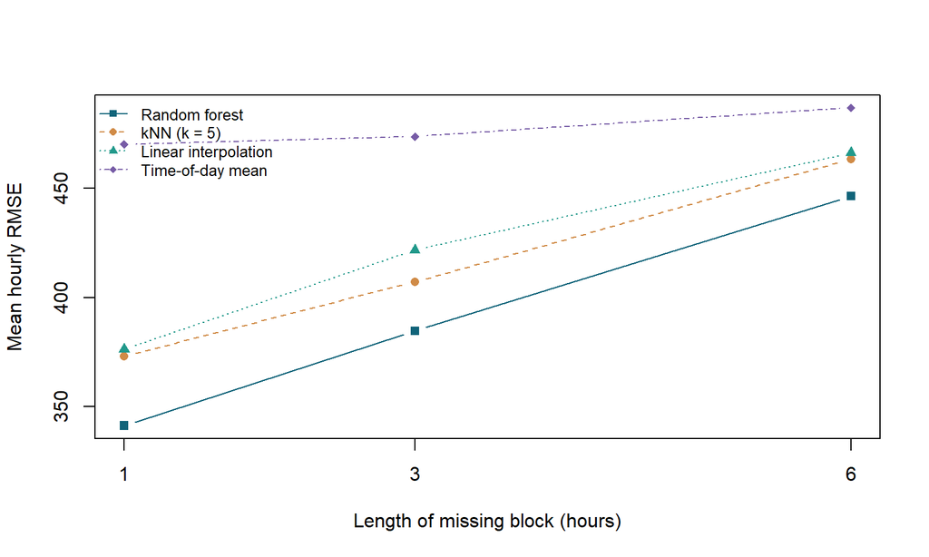

Mean hourly reconstruction RMSE by missing-block length, using archived simulation summaries.

```r
rmse_matrix <- xtabs(mean_hourly_RMSE ~ method + gap_hours, data = recon)
rmse_matrix <- rmse_matrix[method_order, c("1", "3", "6"), drop = FALSE]
matplot(c(1, 3, 6), t(rmse_matrix), type = "b", pch = 15:18,
        lty = 1:4, col = c("#11647a", "#d08b47", "#22998b", "#775ca6"), xlab = "Length of missing block (hours)",
        ylab = "Mean hourly RMSE", xaxt = "n")
axis(1, at = c(1, 3, 6))
legend("topleft", legend = rownames(rmse_matrix),
       col = c("#11647a", "#d08b47", "#22998b", "#775ca6"), lty = 1:4, pch = 15:18, cex = 0.8, bty = "n")
```

In these archived results, random forest had the lowest hourly RMSE at each gap length. For six-hour blocks, random forest’s hourly RMSE was approximately 447, whereas the corresponding value for kNN was approximately 463. The distinction between reconstruction quality and downstream inference becomes important below.

## Regression inference

The regression outcomes were simulated using the original reference exposure, age, and sex. Ordinary least squares models were then fitted with the **reconstructed** exposure instead of the true one. The usual confidence intervals treated the reconstructed exposure as observed, without explicitly propagating the uncertainty of single reconstruction.

```r
inference <- inference[
  order(inference$gap_hours,
        match(inference$method, c("Oracle", method_order))),
]

regression_display <- data.frame(
  `Gap (hours)` = inference$gap_hours,
  `Method` = inference$method,
  `Mean beta` = sprintf("%.4f", inference$mean_beta),
  `Coefficient bias` = sprintf("%+.4f", inference$bias),
  `Mean model SE` = sprintf("%.4f", inference$mean_model_SE),
  `95% CI coverage` = sprintf("%.2f%%", 100 * inference$coverage),
  check.names = FALSE
)
knitr::kable(
  regression_display, align = c("r", "l", "r", "r", "r", "r"),
  caption = "Regression summaries from 4,000 fits per configuration; the oracle uses the true exposure."
)
```

Regression summaries from 4,000 fits per configuration; the oracle uses the true exposure.

| Gap (hours) | Method | Mean beta | Coefficient bias | Mean model SE | 95% CI coverage |
| --- | --- | --- | --- | --- | --- |
| 0 | Oracle | 0.5000 | +0.0000 | 0.0170 | 95.47% |
| 1 | Random forest | 0.5013 | +0.0013 | 0.0172 | 95.23% |
| 1 | kNN (k = 5) | 0.5015 | +0.0015 | 0.0172 | 95.00% |
| 1 | Linear interpolation | 0.4968 | -0.0032 | 0.0170 | 95.25% |
| 1 | Time-of-day mean | 0.5194 | +0.0194 | 0.0179 | 81.10% |
| 3 | Random forest | 0.5148 | +0.0148 | 0.0181 | 87.17% |
| 3 | kNN (k = 5) | 0.5025 | +0.0025 | 0.0177 | 95.03% |
| 3 | Linear interpolation | 0.4748 | -0.0252 | 0.0169 | 67.40% |
| 3 | Time-of-day mean | 0.5453 | +0.0453 | 0.0196 | 36.80% |
| 6 | Random forest | 0.5536 | +0.0536 | 0.0212 | 28.82% |
| 6 | kNN (k = 5) | 0.5057 | +0.0057 | 0.0198 | 95.10% |
| 6 | Linear interpolation | 0.4096 | -0.0904 | 0.0164 | 0.00% |
| 6 | Time-of-day mean | 0.5607 | +0.0607 | 0.0227 | 23.30% |

With six-hour gaps, the lower-RMSE random forest reconstruction yielded a mean coefficient of approximately 0.554 and 28.8% coverage of nominal 95% confidence intervals. In contrast, kNN yielded a mean coefficient of approximately 0.506 and 95.1% coverage. This comparison describes **this particular simulation**, not a universal ranking of these algorithms.

## Coefficient distortion and the FWL projection

The Frisch–Waugh–Lovell theorem expresses the coefficient of the reconstructed exposure after removing the linear contributions of the other regressors. Let $\mathbf{x}$ be the reference standardized exposure, $\widehat{\mathbf{x}}$ the reconstructed standardized exposure, and $M_Z$ the residual-maker matrix for the intercept, age, and sex. Then the expected fitted coefficient, conditional on these covariates, is

$$E(\widehat{\beta}\mid \mathbf{x},\widehat{\mathbf{x}}, Z)
= \beta\,\lambda,
\qquad
\lambda =
\frac{\widehat{\mathbf{x}}^{\mathsf T} M_Z \mathbf{x}}
{\widehat{\mathbf{x}}^{\mathsf T} M_Z \widehat{\mathbf{x}}}.$$

The factor $\lambda$ measures the conditional distortion of the coefficient in this model. It is not minimized by the hourly RMSE criterion. In the archived output, $\lambda$ was calculated separately within each masking replication and averaged over 20 replications.

```r
lambda_display <- data.frame(
  `Gap (hours)` = recon$gap_hours,
  `Method` = recon$method,
  `Mean lambda` = sprintf("%.4f", recon$mean_lambda),
  `Projected beta` = sprintf("%.4f", recon$mean_projected_beta),
  check.names = FALSE
)
knitr::kable(lambda_display,
             caption = "Mean coefficient distortion factors and projected coefficients.")
```

Mean coefficient distortion factors and projected coefficients.

| Gap (hours) | Method | Mean lambda | Projected beta |
| --- | --- | --- | --- |
| 1 | Random forest | 1.0026 | 0.5013 |
| 1 | kNN (k = 5) | 1.0028 | 0.5014 |
| 1 | Linear interpolation | 0.9934 | 0.4967 |
| 1 | Time-of-day mean | 1.0386 | 0.5193 |
| 3 | Random forest | 1.0293 | 0.5147 |
| 3 | kNN (k = 5) | 1.0047 | 0.5024 |
| 3 | Linear interpolation | 0.9493 | 0.4747 |
| 3 | Time-of-day mean | 1.0905 | 0.5452 |
| 6 | Random forest | 1.1068 | 0.5534 |
| 6 | kNN (k = 5) | 1.0109 | 0.5055 |
| 6 | Linear interpolation | 0.8191 | 0.4095 |
| 6 | Time-of-day mean | 1.1209 | 0.5605 |

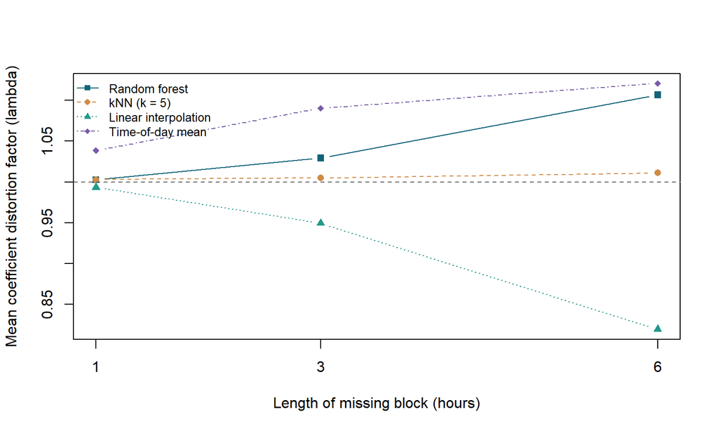

Mean lambda distortion factors from the 20-mask primary analysis. The horizontal dashed line marks lambda = 1.

```r
lambda_matrix <- xtabs(mean_lambda ~ method + gap_hours, data = recon)
lambda_matrix <- lambda_matrix[method_order, c("1", "3", "6"), drop = FALSE]
matplot(c(1, 3, 6), t(lambda_matrix), type = "b", pch = 15:18,
        lty = 1:4, col = c("#11647a", "#d08b47", "#22998b", "#775ca6"), xlab = "Length of missing block (hours)",
        ylab = "Mean coefficient distortion factor (lambda)", xaxt = "n")
axis(1, at = c(1, 3, 6))
abline(h = 1, lty = 2, col = "gray40")
legend("topleft", legend = rownames(lambda_matrix),
       col = c("#11647a", "#d08b47", "#22998b", "#775ca6"), lty = 1:4, pch = 15:18, cex = 0.8, bty = "n")
```

## Comparison with saved manuscript tables

The manuscript-table audit compares archived full-precision summaries with the original reported Tables 1 and 2. Every check must pass for the document to render. Reported discrepancies reflect publication rounding, not Monte Carlo uncertainty.

```r
compare_rounded <- function(source, target, left, right,
                            multiplier = 1, tolerance = 0.0051) {
  joined <- merge(source, target,
                  by.x = c("gap_hours", "method"),
                  by.y = c("Gap_hours", "Method"),
                  sort = FALSE)
  stopifnot(nrow(joined) == nrow(target))
  max_difference <- max(abs(joined[[left]] * multiplier - joined[[right]]))
  stopifnot(is.finite(max_difference), max_difference <= tolerance)
  invisible(max_difference)
}

for (pair in list(
  c("mean_hourly_RMSE", "Hourly_RMSE"),
  c("mean_exposure_RMSE", "Exposure_RMSE"),
  c("mean_exposure_Bias", "Exposure_Bias")
)) compare_rounded(recon, saved_table1, pair[1], pair[2])
compare_rounded(recon, saved_table1,
                "mean_projected_beta", "Projected_Beta",
                tolerance = 0.000051)

for (pair in list(
  c("mean_beta", "Mean_Beta"),
  c("bias", "Bias"),
  c("empirical_SD", "Empirical_SD"),
  c("mean_model_SE", "Mean_Model_SE"),
  c("mean_CI_width", "Mean_CI_Width")
)) compare_rounded(inference, saved_table2, pair[1], pair[2],
                   tolerance = 0.000051)
compare_rounded(inference, saved_table2,
                "coverage", "Coverage_percent",
                multiplier = 100, tolerance = 0.0051)

audit_metrics <- data.frame(
  `Manuscript metric` = c(
    "Table 1: hourly RMSE", "Table 1: exposure RMSE",
    "Table 1: exposure bias", "Table 1: projected beta",
    "Table 2: fitted coefficient", "Table 2: coefficient bias",
    "Table 2: empirical SD", "Table 2: mean model SE",
    "Table 2: mean CI width", "Table 2: 95% coverage (percentage points)"
  ),
  `Maximum absolute discrepancy` = c(
    compare_rounded(recon, saved_table1, "mean_hourly_RMSE", "Hourly_RMSE"),
    compare_rounded(recon, saved_table1, "mean_exposure_RMSE", "Exposure_RMSE"),
    compare_rounded(recon, saved_table1, "mean_exposure_Bias", "Exposure_Bias"),
    compare_rounded(recon, saved_table1, "mean_projected_beta", "Projected_Beta", tolerance=.000051),
    compare_rounded(inference, saved_table2, "mean_beta", "Mean_Beta", tolerance=.000051),
    compare_rounded(inference, saved_table2, "bias", "Bias", tolerance=.000051),
    compare_rounded(inference, saved_table2, "empirical_SD", "Empirical_SD", tolerance=.000051),
    compare_rounded(inference, saved_table2, "mean_model_SE", "Mean_Model_SE", tolerance=.000051),
    compare_rounded(inference, saved_table2, "mean_CI_width", "Mean_CI_Width", tolerance=.000051),
    compare_rounded(inference, saved_table2, "coverage", "Coverage_percent", multiplier=100, tolerance=.0051)
  ),
  `Verification` = "PASS",
  check.names=FALSE
)
audit_metrics$`Maximum absolute discrepancy` <-
  formatC(audit_metrics$`Maximum absolute discrepancy`, digits=6, format="f")
knitr::kable(audit_metrics, caption=
  "Maximum differences between original archived precision-level summaries and the saved manuscript Tables 1 and 2. All checks must pass for the website to render.")
```

Maximum differences between original archived precision-level summaries and the saved manuscript Tables 1 and 2. All checks must pass for the website to render.

| Manuscript metric | Maximum absolute discrepancy | Verification |
| --- | --- | --- |
| Table 1: hourly RMSE | 0.004962 | PASS |
| Table 1: exposure RMSE | 0.004677 | PASS |
| Table 1: exposure bias | 0.003281 | PASS |
| Table 1: projected beta | 0.000048 | PASS |
| Table 2: fitted coefficient | 0.000049 | PASS |
| Table 2: coefficient bias | 0.000049 | PASS |
| Table 2: empirical SD | 0.000048 | PASS |
| Table 2: mean model SE | 0.000048 | PASS |
| Table 2: mean CI width | 0.000048 | PASS |
| Table 2: 95% coverage (percentage points) | 0.005000 | PASS |

```r
cat("PASS: all ten manuscript-table verification tests are within the recorded rounding precision.")
```

```
## PASS: all ten manuscript-table verification tests are within the recorded rounding precision.
```

# Study design

The prespecified methodological comparison assesses whether lower hourly reconstruction error corresponds to reduced coefficient bias and nominal regression confidence-interval coverage.

The primary analysis used 3,635 selected participants from the combined NHANES 2011–2014 cycles. For each of 20 masking replications, one complete eight-hour window was selected per participant. The second hour, hours two through four, or hours two through seven were artificially masked, producing gaps of 1, 3, or 6 consecutive hours. The four reconstruction methods were linear interpolation, time-of-day mean, $k$-nearest neighbors ($k=5$), and random forest.

For each completed eight-hour window, the exposure was the average hourly activity:

$$X_i = \frac{1}{8}\sum_{h=1}^{8} A_{ih}.$$

Simulated continuous outcomes followed an age- and sex-adjusted linear model with the **true standardized activity coefficient** $\beta=0.5$. Each method–gap configuration was assessed in 20 masking replications and 200 outcome simulations per replication, giving 4,000 regression fits.

The NHANES weights were not used in these methodological simulations. The reported performance measures therefore describe the selected cohort and simulation mechanism; they are **not nationally representative estimates**.

# Data sources and analytic cohort

The following provenance analysis documents how the **recorded NHANES hourly accelerometry data** became the reference measurements for the final 2011–2014 simulation. The workflow is traced to the original scripts, not reconstructed from the manuscript description alone. Only small archived results are loaded here; the expensive data preparation and imputation procedures are **not** executed during website rendering.

## Input files and source measurements

The study combines the NHANES 2011–2012 (`G`) and 2013–2014 (`H`) cycles. The archived raw inputs are the hourly physical-activity-monitor files (`PAXHR_G`, `PAXHR_H`), monitor header files (`PAXHD_G`, `PAXHD_H`), demographics files (`DEMO_G`, `DEMO_H`), and body-measures files (`BMX_G`, `BMX_H`). The primary reconstruction outcome is `PAXMTSH`: an **hourly sum of MIMS activity**, rather than raw acceleration sampled at 80 Hz.

```r
original_data_files <- c(
  "PAXHR_G.xpt", "PAXHR_H.xpt", "PAXHD_G.xpt", "PAXHD_H.xpt",
  "DEMO_G.xpt", "DEMO_H.xpt", "BMX_G.xpt", "BMX_H.xpt"
)
original_data_paths <- file.path("Data", "Raw", original_data_files)
if (!all(file.exists(original_data_paths))) {
  stop("Missing NHANES raw file(s): ",
       paste(original_data_paths[!file.exists(original_data_paths)], collapse = ", "))
}
raw_manifest <- data.frame(
  `Original input` = original_data_paths,
  `File size (MB)` = round(file.info(original_data_paths)$size / 1024^2, 2),
  check.names = FALSE
)
knitr::kable(raw_manifest, caption = "Original NHANES data files present in the research archive. The XPT files are not loaded during this render.")
```

Original NHANES data files present in the research archive. The XPT files are not loaded during this render.

| Original input | File size (MB) |
| --- | --- |
| Data/Raw/PAXHR_G.xpt | 122.25 |
| Data/Raw/PAXHR_H.xpt | 138.05 |
| Data/Raw/PAXHD_G.xpt | 0.37 |
| Data/Raw/PAXHD_H.xpt | 0.42 |
| Data/Raw/DEMO_G.xpt | 3.58 |
| Data/Raw/DEMO_H.xpt | 3.66 |
| Data/Raw/BMX_G.xpt | 1.86 |
| Data/Raw/BMX_H.xpt | 1.95 |

The NHANES hourly data documentation is available from the [2011–2012 survey cycle](https://wwwn.cdc.gov/Nchs/Data/Nhanes/Public/2011/DataFiles/PAXHR_G.htm) and the [2013–2014 cycle](https://wwwn.cdc.gov/Nchs/Data/Nhanes/Public/2013/DataFiles/PAXHR_H.htm). The header files are used to reconstruct time of day, and demographics supply age and sex. Body measurements are retained for the separate real-BMI application, not for constructing the primary synthetic outcome.

## Data processing and eligibility criteria

The initial exploratory `Data_Cleaning.R` processed the 2013–2014 cycle. The final **combined-cycle** implementation was developed in scripts `40.R`, `41.R`, and `43.R`. We document the latter as the source of the final analytic cohort, with the subsequent repeated-window selection performed in `64.R`.

```r
preparation_sources <- data.frame(
  `Original file` = c("Data_Cleaning.R", "40.R", "41.R", "43.R", "44.R", "63.R", "64.R"),
  `Role in the original research` = c(
    "Initial 2013--2014 cleaning and data exploration",
    "Combine G/H hourly, header, demographic and body-measure files",
    "Cycle-neutral cleaning, valid days, clean hours, time reconstruction",
    "Final eight-hour candidate-window detector and combined-cycle eligibility",
    "One-window-per-participant initial selection",
    "Candidate window counts and repeated-selection checks",
    "Final 20 replicated selections and archived reference exposures"
  ), check.names = FALSE
)
knitr::kable(preparation_sources, caption = "Provenance of the NHANES preparation steps in the original code archive.")
```

Provenance of the NHANES preparation steps in the original code archive.

| Original file | Role in the original research |
| --- | --- |
| Data_Cleaning.R | Initial 2013–2014 cleaning and data exploration |
| 40.R | Combine G/H hourly, header, demographic and body-measure files |
| 41.R | Cycle-neutral cleaning, valid days, clean hours, time reconstruction |
| 43.R | Final eight-hour candidate-window detector and combined-cycle eligibility |
| 44.R | One-window-per-participant initial selection |
| 63.R | Candidate window counts and repeated-selection checks |
| 64.R | Final 20 replicated selections and archived reference exposures |

The original scripts are available in `R results/R scripts/`, except for `Data_Cleaning.R`, which is at the top level. The excerpts below are **quoted directly from those scripts**. They explain the implemented rules; they are not executed a second time when the page is knitted.

### Daily wear and participant eligibility

The combined-cycle cleaning function first attaches age from the demographics files and restricts the final analysis to participants **aged at least six years**. It considers monitoring days **2 through 8**, excluding the typically partial first and ninth days. For every available hour, wear minutes are the sum of awake-wear and sleep-wear minutes:

$$W_{idh}=\mathrm{PAXWWMH}_{idh}+\mathrm{PAXSWMH}_{idh}.$$

Daily wear time is obtained by summing these minutes across that monitoring day. A day is considered valid when it contains **at least 960 minutes (16 hours)** of wear. The code constructs all seven possible days for each participant, assigning zero wear to any completely absent day before counting valid days. A participant must have **at least four valid days**.

Selected source lines from `41.R` make the last rule explicit:

**Original R source · 41.RLines 259–281**

```
  participant_wear <- pax_day_complete %>%

    group_by(SEQN) %>%

    summarise(

      n_valid_days =
        sum(valid_day),

      .groups = "drop"
    )


  # ----------------------------------------------------------
  # 7. Participant eligibility
  #
  # At least 4 valid full days
  # ----------------------------------------------------------

  eligible_participants <- participant_wear %>%
    filter(
      n_valid_days >= 4
    )
```

### Hour-level quality control

For eligible participants, the original code defines a clean hour as one with all 60 minutes valid, no quality-control flag, no nonwear or unknown minutes, and a total of 60 minutes classified as awake or asleep wear:

$$\begin{aligned}
\mathrm{PAXVMH}&=60, & \mathrm{PAXQFH}&=0,\\
\mathrm{PAXNWMH}&=0, & \mathrm{PAXUMH}&=0,\\
\mathrm{PAXWWMH}+\mathrm{PAXSWMH}&=60.
\end{aligned}$$

**Original R source · 41.RLines 290–313**

```
  pax_quality <- hour_data %>%

    mutate(

      wear_minutes =
        PAXWWMH +
        PAXSWMH,

      clean_hour =
        coalesce(

          PAXVMH == 60 &
          PAXQFH == 0 &
          PAXNWMH == 0 &
          PAXUMH == 0 &
          wear_minutes == 60,

          FALSE
        )
    ) %>%

    filter(
      PAXDAYH %in% 2:8
    )
```

This clean-hour flag checks wear and quality fields. **Availability of `PAXMTSH` is additionally checked in the later final-window validation**, rather than being part of the clean-hour Boolean definition above. Keeping these steps distinct reflects the original implementation.

### Recovering clock time and consecutive hours

The monitor header variable `PAXFTIME` provides a first-recorded clock time for header records satisfying `PAXSTS == 1`. The original combined-cycle code parses this time and uses the sampling index `PAXSSNHP` to derive each hourly record’s clock hour. At the documented sampling frequency of 80 Hz, consecutive hours are separated by

$$60\times60\times80=288{,}000\ \text{samples}.$$

The final eight-hour detector in `43.R` requires all eight hourly records to satisfy the clean-hour criterion, all eight to have a known reconstructed time of day, and successive start-sample indices to be separated by exactly 288,000 samples.

**Original R source · 43.RLines 76–125**

```
      block8 =

        # -----------------------------------------------
        # All 8 hours must be clean
        # -----------------------------------------------

        clean_hour &

        lead(clean_hour, 1, default = FALSE) &
        lead(clean_hour, 2, default = FALSE) &
        lead(clean_hour, 3, default = FALSE) &
        lead(clean_hour, 4, default = FALSE) &
        lead(clean_hour, 5, default = FALSE) &
        lead(clean_hour, 6, default = FALSE) &
        lead(clean_hour, 7, default = FALSE) &

        # -----------------------------------------------
        # All 8 hours must have known clock time
        # -----------------------------------------------

        !is.na(hour_of_day) &

        !is.na(lead(hour_of_day, 1)) &
        !is.na(lead(hour_of_day, 2)) &
        !is.na(lead(hour_of_day, 3)) &
        !is.na(lead(hour_of_day, 4)) &
        !is.na(lead(hour_of_day, 5)) &
        !is.na(lead(hour_of_day, 6)) &
        !is.na(lead(hour_of_day, 7)) &

        # -----------------------------------------------
        # Ensure true consecutive hourly records
        # -----------------------------------------------

        lead(PAXSSNHP, 1) - PAXSSNHP == 288000 &
        lead(PAXSSNHP, 2) - PAXSSNHP == 576000 &
        lead(PAXSSNHP, 3) - PAXSSNHP == 864000 &
        lead(PAXSSNHP, 4) - PAXSSNHP == 1152000 &
        lead(PAXSSNHP, 5) - PAXSSNHP == 1440000 &
        lead(PAXSSNHP, 6) - PAXSSNHP == 1728000 &
        lead(PAXSSNHP, 7) - PAXSSNHP == 2016000
    ) %>%
    ungroup()


  candidate_starts <- all_hours %>%
    filter(block8)
```

## From candidate windows to repeated simulation samples

Script `43.R` constructs the combined-cycle candidate eight-hour windows. Script `64.R` verifies that the eligible candidate pool contains **20,049 windows from 3,635 distinct participants** (these values are assertions in the original generating code). The pool is larger than the participant count because one person may contribute more than one candidate window.

The final simulation randomly selects **one candidate window per participant in each of 20 replications**. The function in `64.R` uses the seed `20262000 + r` for replication `r`; thus, the same selection can be regenerated if the candidate pool is reconstructed in the same order. A previously generated one-window selection in `44.R` is an earlier stage, not the final 20-replication analysis.

### Archived cohort-selection verification

The following small archived files are loaded directly from the original folder. This verifies the final cohort, its cycle composition, the repeated selections, and reference-exposure completeness. **No random forest is fitted and no outcome is simulated.**

```r
window_dir <- file.path("R results", "Final 2011-2014", "Inference", "Repeated masking")
selection_csv <- file.path(window_dir, "selection_validation.csv")
selected_rds <- file.path(window_dir, "selected_windows_20_replicates.rds")
true_rds <- file.path(window_dir, "true_exposures_20_replicates.rds")
window_inputs <- c(selection_csv, selected_rds, true_rds)
if (!all(file.exists(window_inputs))) {
  stop("Archived window-selection file(s) missing: ",
       paste(window_inputs[!file.exists(window_inputs)], collapse = ", "))
}

selection_validation <- read.csv(selection_csv, check.names = FALSE)
selected_windows <- readRDS(selected_rds)
true_exposures <- readRDS(true_rds)

stopifnot(
  identical(sort(as.character(selection_validation$cycle)),
            c("2011-2012", "2013-2014")),
  all(selection_validation$replications == 20L),
  all(selection_validation$minimum_participants ==
      selection_validation$maximum_participants),
  all(selection_validation$total_missing_starts == 0L),
  sum(selection_validation$minimum_participants) == 3635L,
  nrow(selected_windows) == 20L * 3635L,
  nrow(true_exposures) == 20L * 3635L,
  all(c("SEQN", "cycle", "replicate", "window_start") %in% names(selected_windows)),
  all(c("SEQN", "cycle", "replicate", "X_true", "X_true_z",
        "n_hours", "unique_hours", "all_clean",
        "all_MIMS_observed", "all_clock_hours_known") %in% names(true_exposures)),
  !anyNA(selected_windows$window_start),
  !anyDuplicated(selected_windows[c("replicate", "SEQN")]),
  length(unique(selected_windows$replicate)) == 20L,
  all(true_exposures$n_hours == 8L),
  all(true_exposures$unique_hours == 8L),
  all(true_exposures$all_clean),
  all(true_exposures$all_MIMS_observed),
  all(true_exposures$all_clock_hours_known),
  all(is.finite(true_exposures$X_true)),
  all(is.finite(true_exposures$X_true_z))
)

selected_cycle_counts <- as.data.frame(
  table(selected_windows$cycle, selected_windows$replicate),
  stringsAsFactors = FALSE
)
names(selected_cycle_counts) <- c("cycle", "replicate", "participants")
for (j in seq_len(nrow(selection_validation))) {
  expected <- selection_validation$minimum_participants[j]
  actual <- selected_cycle_counts$participants[
    selected_cycle_counts$cycle == selection_validation$cycle[j]
  ]
  stopifnot(length(actual) == 20L, all(actual == expected))
}

knitr::kable(
  data.frame(
    `NHANES cycle` = selection_validation$cycle,
    `Participants per replication` = selection_validation$minimum_participants,
    `Number of replications` = selection_validation$replications,
    `Missing window starts` = selection_validation$total_missing_starts,
    check.names = FALSE
  ),
  caption = "Cycle-specific sample sizes recovered from archived selection validation."
)
```

Cycle-specific sample sizes recovered from archived selection validation.

| NHANES cycle | Participants per replication | Number of replications | Missing window starts |
| --- | --- | --- | --- |
| 2011-2012 | 1787 | 20 | 0 |
| 2013-2014 | 1848 | 20 | 0 |

```r
cat("\nPASS: ", format(nrow(selected_windows), big.mark = ","),
    " participant-window selections and ",
    format(nrow(true_exposures), big.mark = ","),
    " complete reference exposures validated from archived RDS files.", sep = "")
```

```
##
## PASS: 72,700 participant-window selections and 72,700 complete reference exposures validated from archived RDS files.
```

The 3,635 participants are the **final selected reference cohort**, not the number of all NHANES participants and not a survey-weighted national population estimate. The repeated selections use the same cohort and may reuse the same window, so the 20 replications are **not independent participant samples**.

```r
# This summary requires only the archived list of selected windows.
distinct_per_person <- tapply(
  selected_windows$window_start,
  selected_windows$SEQN,
  function(x) length(unique(x))
)
selection_variation <- data.frame(
  `Participants checked` = length(distinct_per_person),
  `Same window selected in all 20` = sum(distinct_per_person == 1L),
  `More than one distinct window selected` = sum(distinct_per_person > 1L),
  `Median distinct windows per participant` = median(distinct_per_person),
  `Maximum distinct windows per participant` = max(distinct_per_person),
  check.names = FALSE
)
knitr::kable(selection_variation,
             caption = "Within-participant window-selection variation across 20 masking replications.")
```

Within-participant window-selection variation across 20 masking replications.

| Participants checked | Same window selected in all 20 | More than one distinct window selected | Median distinct windows per participant | Maximum distinct windows per participant |
| --- | --- | --- | --- | --- |
| 3635 | 798 | 2837 | 3 | 19 |

The data preparation and cohort-selection steps are now independently checkable **from the archived outputs**. Recomputing the original 20,049-window candidate pool from the raw `.xpt` files would additionally require executing the original data-cleaning and window-detection scripts in a fresh R session; this website does not claim to have performed that more expensive upstream rerun.

# Missing-block design and reconstruction methods

This section specifies the **artificial missingness design and the four hourly reconstruction algorithms** in the final combined-cycle study. The descriptions and displayed source-code excerpts come from the original numbered scripts, particularly `45.R`, `47.R`, `49.R`, `50.R`, `51.R`, `53.R`, `69.R`, and `70.R`. As in the previous chapter, knitting **does not execute** those original algorithms or retrain random forests.

## Artificial missingness mechanism

Each replication has one recorded, complete eight-hour activity window for each of the 3,635 participants. In the original code, positions are numbered **0 through 7**. Artificially missing positions start at position 1 (the **second** hour) and extend to position $g$, where $g\in\{1,3,6\}$. Position 0 and position 7 remain observed in every design. These are **nested masks**, so the one-hour positions are a subset of the three-hour positions, which are a subset of the six-hour positions.

The recorded hourly value `PAXMTSH` is saved separately as the known *reference* before the artificial mask is applied. It is not made available as an outcome value to an imputation method at a masked position.

**Original R source · 45.RLines 77–109**

```
  # ----------------------------------------------------------
  # 2. Define the masked target interval
  #
  # First masked hour:
  #     window_start + 1 hour
  #
  # Last masked hour:
  #     window_start + gap_hours hours
  # ----------------------------------------------------------

  participant_data <- participant_data %>%

    mutate(

      masked =

        PAXSSNHP >=
          window_start + 1 * 288000 &

        PAXSSNHP <=
          window_start + gap_hours * 288000,

      # Preserve the original MIMS everywhere except
      # the deliberately masked target hours.

      MIMS_observed =
        if_else(
          masked,
          NA_real_,
          PAXMTSH
        )
    )
```

```r
# Derive numbers from the archived final reference selections, not manually entered results.
stopifnot(nrow(selected_windows) == nrow(true_exposures))
reps <- length(unique(selected_windows$replicate))
participants_per_rep <- nrow(selected_windows) / reps
stopifnot(reps == 20L, participants_per_rep == 3635L)

gap_values <- c(1L, 3L, 6L)
mask_design <- data.frame(
  `Gap (hours)` = gap_values,
  `Masked positions (0-based)` = c("1", "1, 2, 3", "1, 2, 3, 4, 5, 6"),
  `Observed positions (0-based)` = c("0, 2--7", "0, 4--7", "0, 7"),
  `Masked hours per replication` = participants_per_rep * gap_values,
  `Masked hours over all 20 selections` = participants_per_rep * reps * gap_values,
  `Observed hours per participant` = 8L - gap_values,
  check.names = FALSE
)
knitr::kable(mask_design,
             caption = "The imposed nested-gap designs; counts are calculated from the archived 20-replication selections.")
```

The imposed nested-gap designs; counts are calculated from the archived 20-replication selections.

| Gap (hours) | Masked positions (0-based) | Observed positions (0-based) | Masked hours per replication | Masked hours over all 20 selections | Observed hours per participant |
| --- | --- | --- | --- | --- | --- |
| 1 | 1 | 0, 2–7 | 3635 | 72700 | 7 |
| 3 | 1, 2, 3 | 0, 4–7 | 10905 | 218100 | 5 |
| 6 | 1, 2, 3, 4, 5, 6 | 0, 7 | 21810 | 436200 | 2 |

These are **artificially withheld values from originally complete records**. Their known values allow direct estimation of reconstruction errors. The gap positions are fixed within each selected window, not randomly assigned to different positions. They do not represent a model for why an accelerometer might naturally have missing data.

## Protection against donor contamination

The construction sets `MIMS_observed = NA` at the target positions while retaining the original values in a separate `truth` component. The repeated-analysis driver checks that the expected number of masked references exists and that the masked `MIMS_observed` entries are missing. The kNN and random-forest feature validation checks that artificially masked targets are excluded from donor records and retain valid predictors. These checks are part of the original **simulation-generating code**, not new model fits performed by this page.

**Original R source · 70.RLines 51–75**

```
    # Create the new missing-data pattern

    mask <- make_masking_experiment(

      reference_hours =
        pam_2011_2014$reference_hours,

      selected_windows = selected,

      gap_hours = gap
    )

    # Verify correct masking

    stopifnot(
      nrow(mask$truth) == 3635 * gap,

      all(is.finite(mask$truth$true_MIMS)),

      all(is.na(
        mask$masked_data$MIMS_observed[
          mask$masked_data$masked
        ]
      ))
    )
```

**Original R source · 70.RLines 117–129**

```
    stopifnot(
      feature_check$participants == 3635,

      feature_check$targets == 3635 * gap,

      feature_check$complete_targets == 3635 * gap,

      feature_check$incomplete_targets == 0,

      feature_check$masked_used_as_donors == 0,

      feature_check$masked_still_observed == 0
    )
```

## The four reconstruction methods

All methods replace **only artificially masked hours**, leaving the unmasked recorded hourly values unchanged. The imputation methods are applied before simulating the regression outcomes; therefore the primary hourly reconstructions do **not** use the simulated health outcome to predict activity.

### Linear interpolation

For each participant, the original function sorts hourly records by the accelerometer sample index and interpolates between available recorded MIMS values with R’s `approx(..., method="linear", rule=1)`. Because the selected gaps have observed boundary values, interpolation within these test windows does not require extrapolation.

**Original R source · 47.RLines 16–53**

```
  imputed_data <- mask_object$masked_data %>%

    group_by(SEQN) %>%

    arrange(
      PAXSSNHP,
      .by_group = TRUE
    ) %>%

    mutate(

      MIMS_linear =

        approx(

          x =
            PAXSSNHP[
              !is.na(MIMS_observed)
            ],

          y =
            MIMS_observed[
              !is.na(MIMS_observed)
            ],

          xout =
            PAXSSNHP,

          method =
            "linear",

          rule =
            1

        )$y
    ) %>%

    ungroup()
```

### Hierarchical time-of-day means

For a masked hour, the time-of-day method follows the hierarchy in `49.R`: first an available **same-participant, same clock-hour** mean, then the **same NHANES cycle and same clock-hour** mean, and finally the **cycle-wide observed** mean. Donors must be clean, unmasked hours with finite recorded MIMS. This is more specific than an unconditional global-mean imputation procedure.

**Original R source · 49.RLines 29–43**

```
  donors <- data %>%

    filter(
      clean_hour,
      !masked,
      !is.na(hour_of_day),
      is.finite(MIMS_observed)
    ) %>%

    select(
      SEQN,
      cycle,
      hour_of_day,
      MIMS_observed
    )
```

**Original R source · 49.RLines 50–103**

```
  person_tod <- donors %>%

    group_by(
      SEQN,
      hour_of_day
    ) %>%

    summarise(

      person_tod_mean =
        mean(MIMS_observed),

      .groups = "drop"
    )


  # ----------------------------------------------------------
  # 3. Cycle-specific time-of-day mean
  #
  # We use separate donor means for 2011-2012
  # and 2013-2014.
  # ----------------------------------------------------------

  cycle_tod <- donors %>%

    group_by(
      cycle,
      hour_of_day
    ) %>%

    summarise(

      cycle_tod_mean =
        mean(MIMS_observed),

      .groups = "drop"
    )


  # ----------------------------------------------------------
  # 4. Overall mean within each NHANES cycle
  # ----------------------------------------------------------

  cycle_overall <- donors %>%

    group_by(cycle) %>%

    summarise(

      cycle_overall_mean =
        mean(MIMS_observed),

      .groups = "drop"
    )
```

### $k$-nearest neighbors ($k=5$)

The final kNN procedure uses 12 predictor features comprising participant characteristics, cyclical time variables, summaries of observed activity, and neighboring observed activity information. In the original function, donors are restricted to clean, observed records, and donor pools are **separate for the two NHANES cycles**. The predictors for both donors and targets are standardized using **donor-only means and standard deviations**. Five nearest donor records are identified using `FNN::get.knnx` (a $k$-d tree search), and their observed MIMS values are averaged.

The exact feature vector and the numerical standardization steps are shown from `50.R` and `51.R`:

**Original R source · 50.RLines 150–163**

```
ml_feature_names <- c(
  "RIDAGEYR",
  "sex_binary",
  "hour_sin",
  "hour_cos",
  "dow_sin",
  "dow_cos",
  "person_mean_MIMS",
  "person_sd_MIMS",
  "prev_clean_MIMS",
  "next_clean_MIMS",
  "hours_since_prev",
  "hours_to_next"
)
```

**Original R source · 51.RLines 110–142**

```
    # --------------------------------------------------------
    # Standardize based ONLY on donor distribution
    # --------------------------------------------------------

    train_means <- colMeans(
      X_train
    )

    train_sds <- apply(
      X_train,
      2,
      sd
    )

    # Protect against constant predictors
    train_sds[
      !is.finite(train_sds) |
        train_sds < 1e-10
    ] <- 1


    X_train_scaled <- scale(
      X_train,
      center = train_means,
      scale = train_sds
    )

    X_target_scaled <- scale(
      X_target,
      center = train_means,
      scale = train_sds
    )
```

**Original R source · 51.RLines 160–182**

```
    # --------------------------------------------------------

    knn_fit <- FNN::get.knnx(
      data = X_train_scaled,
      query = X_target_scaled,
      k = k,
      algorithm = "kd_tree"
    )


    # --------------------------------------------------------
    # Recover actual observed MIMS of the neighbors
    # --------------------------------------------------------

    neighbor_values <- matrix(

      donors$MIMS_observed[
        as.vector(knn_fit$nn.index)
      ],

      nrow = nrow(knn_fit$nn.index),

      ncol = k
```

The displayed code is **the original implementation**, rather than a simplified replacement algorithm; rebuilding the predictors and donor matrices requires the preceding source scripts and the cleaned hourly data.

### Random forest regression

Random forests use the **same 12 predictors** as kNN and fit independent regressions within each NHANES cycle. The original implementation uses `ranger` with **200 trees**, **`mtry = 4`**, **minimum node size 5**, and a reproducible seed determined by the replication and gap configuration. Model training uses only clean, available donor hours; the artificially withheld MIMS values are used later for scoring, not as training responses.

**Original R source · 53.RLines 139–160**

```
    # --------------------------------------------------------
    # 6. Train the random forest
    # --------------------------------------------------------

    rf_model <- ranger::ranger(

      dependent.variable.name = "MIMS_observed",

      data = train_data,

      num.trees = num_trees,

      mtry = mtry,

      min.node.size = min_node_size,

      importance = "none",

      seed = seed,

      num.threads = 2
    )
```

**Original R source · 70.RLines 152–167**

```
    rf_fit <- run_rf_imputation(

      feature_data = features,

      gap_hours = gap,

      num_trees = 200,

      mtry = 4,

      min_node_size = 5,

      seed = as.integer(
        20262000 + rep_number * 10 + gap
      )
    )
```

These hyperparameters document **the method that was actually evaluated**. They do not imply that other forest architectures or hyperparameter choices would have the same inferential performance.

## Reconstructing the participant-level exposure

Let $A_{irh}$ denote the recorded reference value at hour $h$ of the selected window for participant $i$ in replicate $r$, and let $\widehat A^{(m,g)}_{irh}$ be its completed value under method $m$ and gap length $g$. The two eight-hour exposures are

$$X_{ir}=\frac{1}{8}\sum_{h=1}^{8}A_{irh},\qquad
\widehat X_{ir}^{(m,g)}=\frac{1}{8}\sum_{h=1}^{8}\widehat
A_{irh}^{(m,g)}.$$

Because all unmasked hours are preserved, the difference between these exposures is the **sum of prediction errors at the masked hours divided by eight**:

$$\widehat X_{ir}^{(m,g)}-X_{ir}
=\frac{1}{8}\sum_{h\in\mathcal M_g}
\big(\widehat A_{irh}^{(m,g)}-A_{irh}\big).$$

The actual implementation in `69.R` uses this identity and then standardizes reconstructed exposures using the **reference exposure mean and standard deviation**, rather than method-specific standardization:

**Original R source · 69.RLines 73–81**

```
  person_errors <- checked %>%
    mutate(
      error = imputed_MIMS - true_MIMS
    ) %>%
    group_by(SEQN, cycle) %>%
    summarise(
      n_imputed_hours = n(),
      total_error = sum(error),
      .groups = "drop"
```

**Original R source · 69.RLines 99–118**

```
  exposures <- true_exposures %>%
    left_join(
      person_errors,
      by = c("SEQN", "cycle")
    ) %>%
    mutate(
      replicate = replicate_number,
      gap_hours = gap_value,
      method = method_name,

      X_imputed =
        X_true + total_error / 8,

      X_imputed_z =
        (X_imputed - true_activity_mean) /
        true_activity_sd,

      exposure_error =
        X_imputed - X_true
    )
```

## Reconstruction metrics and archived checks

Hourly prediction error is assessed **on withheld hours only**. Participant-level exposure RMSE and exposure bias are assessed on the eight-hour mean. The quantities are related but answer different questions:

$$\operatorname{RMSE}_{\mathrm{hour}}
=\sqrt{\operatorname{mean}_{\mathrm{masked}}\big[(\widehat A-A)^2\big]},
\qquad
\operatorname{RMSE}_{\mathrm{exposure}}
=\sqrt{\operatorname{mean}_{\mathrm{participants}}\big[(\widehat
X-X)^2\big]}.$$

The archived reconstruction summary contains the complete set of **12 method–gap combinations** (four methods and three gap lengths). Its structure and numerical values are validated without refitting an imputation model.

```r
mask_summary_path <- file.path(
  "R results", "Final 2011-2014", "Inference", "Repeated masking",
  "all20_reconstruction_summary.csv"
)
stopifnot(file.exists(mask_summary_path))
mask_summary <- read.csv(mask_summary_path, check.names = FALSE)
expected_methods <- c("Linear interpolation", "Time-of-day mean",
                      "kNN (k = 5)", "Random forest")
expected_combinations <- expand.grid(
  gap_hours = gap_values,
  method = expected_methods,
  stringsAsFactors = FALSE
)
stopifnot(
  nrow(mask_summary) == 12L,
  !anyDuplicated(mask_summary[c("gap_hours", "method")]),
  all(mask_summary$replications == reps),
  identical(sort(unique(mask_summary$gap_hours)), gap_values),
  setequal(mask_summary$method, expected_methods),
  nrow(merge(mask_summary, expected_combinations,
             by = c("gap_hours", "method"))) == 12L,
  all(is.finite(mask_summary$mean_hourly_RMSE)),
  all(is.finite(mask_summary$mean_exposure_RMSE))
)
cat("PASS: original archived summary contains 12 distinct method--gap",
    "configurations, each summarized across 20 selections. No imputation",
    "or model refitting was performed during knitting.")
```

```
## PASS: original archived summary contains 12 distinct method--gap configurations, each summarized across 20 selections. No imputation or model refitting was performed during knitting.
```

The documented masking rules, original source-code excerpts, expected withheld-value counts, and checks against saved results establish traceability of the implemented design. They do not constitute an independent rerun of the complete analysis from raw NHANES data.

# Outcome-generating model and null-effect sensitivity

This analysis separates two related but **distinct** outcome experiments in the original code archive. The primary study repeatedly selects activity windows and generates outcomes with $\beta=0.5$. A separate earlier fixed-mask experiment generates outcomes with $\beta=0$ to assess the false-positive rate. Both are valuable, but their results must not be pooled or described as having the same masking design.

## Main study: outcomes with a known nonzero activity coefficient

For each selected participant window $r$, the original code defines the true standardized eight-hour exposure $X_{ir,z}$. The simulated continuous outcome is

$$Y_{irs}=0.5
X_{ir,z}+0.3\,\mathrm{Age}_{i,z}+0.2\,\mathrm{Sex}_i+\varepsilon_{irs},
\qquad \varepsilon_{irs}\sim N(0,1).$$

The code uses the **same outcome realization** to evaluate the oracle regression and all 12 combinations of four reconstruction methods and three gap lengths within a given masking replication. Each regression adjusts for an intercept, age, and sex. This matched design prevents differences between randomly generated outcomes from driving comparisons between methods within an outcome realization.

`71.R` implements the fast Frisch–Waugh–Lovell (FWL) regression calculations, while `72.R` runs the full repeated-outcome experiment from saved imputation checkpoints. In particular, the outcome seed for masking replication $r$ is `20261008 + 1000 * r`. The original code tests the fast calculations against ordinary `lm()` regression in the pilot phase.

**Original R source · 71.RLines 320–343**

```
  Sxx <- colSums(X_res^2)

  stopifnot(all(is.finite(Sxx)), all(Sxx > 0))

  # Generate outcomes from the true model
  set.seed(seed)

  outcome_mean <-
    0.5 * truth$X_true_z +
    0.3 * truth$age_z +
    0.2 * truth$sex_binary

  Y <- matrix(
    outcome_mean,
    nrow = n,
    ncol = n_sims
  ) +
    matrix(
      rnorm(n * n_sims),
      nrow = n,
      ncol = n_sims
    )
```

**Original R source · 72.RLines 10–68**

```
  repeat_dir,
  "Outcome simulations"
)

dir.create(
  simulation_dir,
  recursive = TRUE,
  showWarnings = FALSE
)


# Validate one completed simulation checkpoint

validate_inference_checkpoint <- function(
    x,
    rep_number,
    n_sims = 200L
) {

  stopifnot(

    is.data.frame(x),

    nrow(x) == 13L * n_sims,

    all(x$replicate == rep_number),

    n_distinct(x$simulation) == n_sims,

    all(table(x$simulation) == 13L),

    anyDuplicated(
      x[c("simulation", "gap_hours", "method")]
    ) == 0,

    all(is.finite(x$beta_hat)),

    all(is.finite(x$model_SE)),

    all(x$model_SE > 0),

    all(is.finite(x$lower_CI)),

    all(is.finite(x$upper_CI)),

    all(x$lower_CI < x$upper_CI),

    !anyNA(x$covers_truth),

    sum(x$method == "Oracle") == n_sims
  )

  TRUE
}


# Run a batch of replications

run_outcome_batch <- function(rep_numbers) {
```

Each selected reference cohort contains 3,635 participants. The full design consists of 20 window-selection replications, each with 200 independently generated outcome realizations. Because each realization is analyzed under the oracle and 12 reconstructed-exposure models, the saved analysis contains $20\times200\times13=52{,}000$ regression records. Each method–gap configuration contributes 4,000 fits; the oracle contributes 4,000. These records **are not 52,000 independent samples of participants**.

```r
checkpoint_dir <- file.path(
  "R results", "Final 2011-2014", "Inference",
  "Repeated masking", "Outcome simulations"
)
checkpoint_paths <- file.path(
  checkpoint_dir,
  sprintf("inference_rep_%02d_200_outcomes.rds", 1:20)
)
stopifnot(all(file.exists(checkpoint_paths)))

# Check the saved checkpoints' presence and sizes without fitting any model.
checkpoint_registry <- data.frame(
  Replication = 1:20,
  `Saved file` = basename(checkpoint_paths),
  `File size (MB)` = round(file.info(checkpoint_paths)$size / 1024^2, 3),
  check.names = FALSE
)
stopifnot(nrow(checkpoint_registry) == 20L)
cat("PASS: all 20 saved outcome-simulation checkpoints are present. ",
    "No outcomes or regressions were regenerated.", sep = "")
```

```
## PASS: all 20 saved outcome-simulation checkpoints are present. No outcomes or regressions were regenerated.
```

## Expected coefficient under reconstructed exposure

Let $\mathbf{x}_r$ and $\widehat{\mathbf{x}}_r$ be the true and reconstructed standardized participant-level exposures in one masking replication. Let $Z$ contain the intercept, standardized age, and sex, and let

$$M_Z=I-Z(Z^{\mathsf T}Z)^{-1}Z^{\mathsf T}.$$

Conditional on the exposure vectors and covariates, the outcome-model error has mean zero. The FWL representation therefore gives

$$E\!\left(\widehat\beta\mid\mathbf{x}_r,
\widehat{\mathbf{x}}_r,Z\right)
=\beta\,\lambda_r,
\qquad
\lambda_r=
\frac{\widehat{\mathbf{x}}_r^{\mathsf T}M_Z\mathbf{x}_r}
{\widehat{\mathbf{x}}_r^{\mathsf T}M_Z\widehat{\mathbf{x}}_r}.$$

In the primary experiment $\beta=0.5$. A $\lambda$ below one reduces the expected positive coefficient; a value above one increases it. These statements describe **coefficient distortion conditional on the specified model**, not a general ranking of interpolation, kNN, or forests. The relevant criterion is not hourly RMSE but a covariate-adjusted covariance-to-variance ratio.

The archived reconstruction summary contains the mean $\lambda$ and corresponding projected coefficient over 20 masking replications. The numerical audit compares these projections with the empirical regression means from 200 outcomes per replication, saved by script `72.R`.

```r
theory_path <- file.path(
  checkpoint_dir, "theory_alignment_summary.csv"
)
stopifnot(file.exists(theory_path))
theory_data <- read.csv(theory_path, check.names = FALSE)

expected_specs <- expand.grid(
  gap_hours = c(1L, 3L, 6L),
  method = c("Linear interpolation", "Time-of-day mean", "kNN (k = 5)", "Random forest"),
  stringsAsFactors = FALSE
)

stopifnot(
  nrow(theory_data) == 12L,
  !anyDuplicated(theory_data[c("gap_hours", "method")]),
  all(theory_data$replications == 20L),
  nrow(merge(theory_data, expected_specs,
             by = c("gap_hours", "method"))) == 12L,
  all(is.finite(theory_data$mean_difference))
)

theory_merged <- merge(
  theory_data,
  read.csv(file.path(
    "R results", "Final 2011-2014", "Inference",
    "Repeated masking", "all20_reconstruction_summary.csv"
  )),
  by = c("gap_hours", "method"), sort = FALSE
)
stopifnot(
  nrow(theory_merged) == 12L,
  max(abs(theory_merged$mean_projected_beta.x -
          theory_merged$mean_projected_beta.y)) < 1e-10
)

avg_abs_diff <- mean(abs(theory_data$mean_difference))
max_abs_diff <- max(abs(theory_data$mean_difference))
max_within_rep_diff <- max(theory_data$maximum_absolute_difference)

verification_table <- data.frame(
  `Comparison` = c(
    "Mean absolute difference across 12 method-gap summaries",
    "Maximum absolute difference across 12 method-gap summaries",
    "Largest absolute difference at the individual mask level"
  ),
  `Absolute difference` = sprintf("%.6f", c(
    avg_abs_diff, max_abs_diff, max_within_rep_diff
  )), check.names = FALSE
)
knitr::kable(verification_table,
  caption = "Numerical agreement of theoretical projections and simulated mean coefficients; all values are calculated from original archived CSVs.")
```

Numerical agreement of theoretical projections and simulated mean coefficients; all values are calculated from original archived CSVs.

| Comparison | Absolute difference |
| --- | --- |
| Mean absolute difference across 12 method-gap summaries | 0.000130 |
| Maximum absolute difference across 12 method-gap summaries | 0.000274 |
| Largest absolute difference at the individual mask level | 0.003428 |

**Interpretation:** The first two rows compare method–gap means **averaged over 20 masks**. The final row is a maximum over individual masking replications, so it is not expected to be as small. This verification does not require rerunning the 4,000 outcomes per configuration.

## Fixed-mask null-effect experiment ($\beta=0$)

Script `62.R` evaluates the **null hypothesis $H_0:\beta=0$** using a single fixed set of reconstructed exposures from the combined 2011–2014 cohort. In that simulation the outcome has no true activity effect:

$$Y_{is}=0.3\,\mathrm{Age}_{i,z}
+0.2\,\mathrm{Sex}_i+\varepsilon_{is},
\qquad \varepsilon_{is}\sim N(0,1).$$

The script generates **500 independent outcome realizations** using seed `20261016`. It uses conventional OLS $t$-tests with 3,631 residual degrees of freedom and records the proportion of $p$-values below 0.05:

$$\widehat\alpha=\frac{1}{500}
\sum_{s=1}^{500}\mathbf{1}\{p_s<0.05\}.$$

Unlike the main 20-mask experiment, this simulation **does not reselect 20 activity windows**. Its saved results cover the oracle plus **five reconstructed-exposure procedures**: the four main methods and an earlier `MICE PMM (mean of 20)` exposure proxy. Here the MICE label means an **average of 20 imputed exposure draws entered as one regression covariate**; it is **not** the outcome-aware, participant-level MICE analysis pooled using Rubin’s rules described later in the paper.

**Original R source · 62.RLines 1–44**

```
# ============================================================
# STEP 19A
# NULL SIMULATION: TRUE ACTIVITY EFFECT = 0
# 500 INDEPENDENT OUTCOMES
# ============================================================

n_null <- 500L
beta_null <- 0

set.seed(20261016)

# Generate independent random errors
null_errors <- matrix(
  rnorm(n_people * n_null),
  nrow = n_people,
  ncol = n_null
)

# Outcome model without an activity effect
null_expected_Y <-
  0.3 * sim_base$age_z +
  0.2 * sim_base$sex_binary

Y_null_matrix <- sweep(
  null_errors,
  1,
  null_expected_Y,
  FUN = "+"
)

# Remove the effects of age, sex, and intercept
Y_null_residual <- qr.resid(
  qr_Z,
  Y_null_matrix
)

null_df <- n_people - 4L
null_tcritical <- qt(0.975, df = null_df)

stopifnot(
  nrow(Y_null_residual) == 3635,
  ncol(Y_null_residual) == 500,
  all(is.finite(Y_null_residual))
)
```

**Original R source · 62.RLines 82–110**

```
    stop("Invalid regression residual sum of squares.")
  }

  # Conventional OLS standard errors
  model_se <- sqrt(
    (residual_ss / null_df) / denominator
  )

  # Test H0: beta = 0
  t_statistics <- beta_estimates / model_se

  p_values <- 2 * pt(
    -abs(t_statistics),
    df = null_df
  )

  tibble(
    gap_hours = gap_value,
    method = method_label,
    replicate = seq_len(n_null),
    estimated_beta = beta_estimates,
    model_SE = model_se,
    p_value = p_values,
    false_positive = p_values < 0.05
  )
}

# ============================================================
# STEP 19C
```

```r
null_result_path <- file.path(
  "R results", "Final 2011-2014", "Inference",
  "fixed_mask_beta0_type1_summary.csv"
)
stopifnot(file.exists(null_result_path))
null_summary <- read.csv(null_result_path, check.names = FALSE)

expected_null_methods <- c(
  "Linear interpolation", "Time-of-day mean", "kNN (k = 5)",
  "Random forest", "MICE PMM (mean of 20)"
)

stopifnot(
  nrow(null_summary) == 16L,
  !anyDuplicated(null_summary[c("gap_hours", "method")]),
  sum(null_summary$gap_hours == 0L) == 1L,
  sum(null_summary$gap_hours != 0L) == 15L,
  all(null_summary$simulations == 500L),
  setequal(null_summary$method[null_summary$gap_hours != 0L],
           expected_null_methods),
  all(null_summary$false_positives >= 0L),
  all(null_summary$false_positives <= 500L),
  max(abs(null_summary$false_positives / null_summary$simulations -
          null_summary$Type_I_error)) < 1e-12
)

null_order <- c("Oracle (true activity)", expected_null_methods)
null_summary <- null_summary[order(
  null_summary$gap_hours,
  match(null_summary$method, null_order)
), ]

null_display <- data.frame(
  `Gap (hours)` = null_summary$gap_hours,
  `Exposure` = null_summary$method,
  `Null outcomes` = null_summary$simulations,
  `False rejections` = null_summary$false_positives,
  `Type I error` = sprintf("%.1f%%", 100 * null_summary$Type_I_error),
  check.names = FALSE
)
knitr::kable(null_display,
 caption = "Fixed-mask, beta=0 experiment: empirical Type I error from 500 saved outcome realizations per exposure. This is not the main 20-mask simulation.")
```

Fixed-mask, beta=0 experiment: empirical Type I error from 500 saved outcome realizations per exposure. This is not the main 20-mask simulation.

| Gap (hours) | Exposure | Null outcomes | False rejections | Type I error |
| --- | --- | --- | --- | --- |
| 0 | Oracle (true activity) | 500 | 30 | 6.0% |
| 1 | Linear interpolation | 500 | 30 | 6.0% |
| 1 | Time-of-day mean | 500 | 26 | 5.2% |
| 1 | kNN (k = 5) | 500 | 29 | 5.8% |
| 1 | Random forest | 500 | 29 | 5.8% |
| 1 | MICE PMM (mean of 20) | 500 | 28 | 5.6% |
| 3 | Linear interpolation | 500 | 24 | 4.8% |
| 3 | Time-of-day mean | 500 | 27 | 5.4% |
| 3 | kNN (k = 5) | 500 | 30 | 6.0% |
| 3 | Random forest | 500 | 27 | 5.4% |
| 3 | MICE PMM (mean of 20) | 500 | 26 | 5.2% |
| 6 | Linear interpolation | 500 | 30 | 6.0% |
| 6 | Time-of-day mean | 500 | 23 | 4.6% |
| 6 | kNN (k = 5) | 500 | 31 | 6.2% |
| 6 | Random forest | 500 | 33 | 6.6% |
| 6 | MICE PMM (mean of 20) | 500 | 33 | 6.6% |

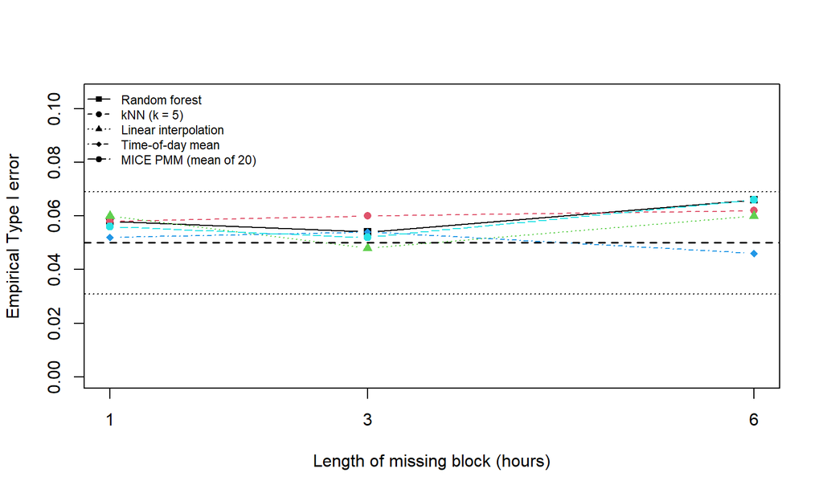

Fixed-mask empirical Type I error by gap length. Dashed line: nominal 5%. Dotted lines: an approximate 95% Monte Carlo range for 500 independent null outcomes at a true 5% rejection probability.

```r
null_methods <- c("Random forest", "kNN (k = 5)",
                  "Linear interpolation", "Time-of-day mean",
                  "MICE PMM (mean of 20)")
null_plot <- null_summary[null_summary$gap_hours %in% c(1, 3, 6), ]
null_mat <- xtabs(Type_I_error ~ method + gap_hours, data = null_plot)
null_mat <- null_mat[null_methods, c("1", "3", "6"), drop = FALSE]
matplot(c(1, 3, 6), t(null_mat), type = "b", pch = 15:19,
        lty = 1:5, xlab = "Length of missing block (hours)",
        ylab = "Empirical Type I error", xaxt = "n", ylim = c(0, 0.105))
axis(1, at = c(1, 3, 6))
abline(h = .05, lty = 2, lwd = 1.5)
mc_se <- sqrt(.05 * .95 / 500)
abline(h = .05 + c(-1, 1) * 1.96 * mc_se, lty = 3)
legend("topleft", legend = rownames(null_mat),
       lty = 1:5, pch = 15:19, cex = .73, bty = "n")
```

Across the saved fixed-mask null results, observed rejection rates range from 4.6% to 6.6%. The oracle rejection rate is 6.0%. Variations of a few percentage points are plausible with 500 independent null outcomes; these summaries do **not** establish equal performance under nonzero effects or other missingness configurations.

### Why approximately correct null tests can coexist with biased nonzero-effect estimates

The coefficient projection explains this apparent paradox. Under the stated outcome model,

$$E(\widehat\beta\mid\mathbf{x},\widehat{\mathbf{x}},Z)
=\beta\lambda.$$

When $\beta=0$, the conditional expected coefficient equals zero regardless of $\lambda$, provided the reconstructed exposure is fixed independently of the simulated outcome errors. Under the independent Gaussian-error model and standard OLS assumptions, nominal null tests can remain correctly calibrated **even if** a reconstruction procedure gives $\lambda$ far from one. Under $\beta=0.5$, by contrast, the same $\lambda$ produces systematic coefficient distortion and can contribute to poor interval coverage.

The fixed-mask null experiment therefore checks a **different inferential property** from coefficient bias and 95% coverage under the main nonzero-effect simulation. It does not replace the need to assess both.

# Outcome-aware MICE: participant-level sensitivity study

This sensitivity analysis addresses a **distinct** missing-exposure experiment from the original research archive. The primary analysis withholds **hourly** MIMS measurements from eight-hour windows and reconstructs them using four single-imputation methods. Here, the missing target is the **participant-level standardized eight-hour mean exposure itself**. The imputation also includes the simulated outcome as an auxiliary predictor and represents uncertainty through multiple completed datasets and Rubin’s pooling rules. These differences preclude treating the two experiments as a head-to-head comparison of methods under an identical design.

All results below come directly from the original archived CSV and RDS files generated primarily by `77.R`, `78.R`, `79.R`, and `80.R`. The website **does not rerun MICE or simulate any new outcomes**.

## Missingness mechanism, cohort and variables

The sensitivity experiment is restricted to the **2011–2012 NHANES cycle** with 1,787 eligible participants. Within one artificial missingness assignment, **1,251 (approximately 70%)** participant-level standardized activity exposures are withheld completely at random, leaving **536 (approximately 30%)** observed exposures. The missingness indicator was assigned independently of the reference exposure, covariates, and simulated outcomes. The original recorded first and last hours of the reference window remain available as auxiliary information; **this does not mean that six individual hourly observations were imputed in this experiment**.

For each outcome realization, the original code imputes `X_observed_z` using predictive mean matching (PMM) conditional on the following seven predictors: the simulated outcome `Y`, standardized age `age_z`, sex `sex_binary`, the first and last observed hourly activity measurements (`boundary_start`, `boundary_end`), and cyclical start-time terms (`start_sin`, `start_cos`). Because `Y` changes between outcome realizations, the MICE procedure is performed separately for each one. The outcome-generating coefficient remains $\beta=0.5$.

**Original R source · 77.RLines 27–81**

```
# Only activity is imputed

mi_person_methods <- mice::make.method(mi_person_input)

mi_person_methods[] <- ""

mi_person_methods["X_observed_z"] <- "pmm"


# Create predictor matrix

mi_person_predictors <- mice::make.predictorMatrix(
  mi_person_input
)

mi_person_predictors[,] <- 0L


# Predict missing activity using outcome,
# demographics, boundaries and start time

person_predictor_names <- c(
  "Y",
  "age_z",
  "sex_binary",
  "boundary_start",
  "boundary_end",
  "start_sin",
  "start_cos"
)

mi_person_predictors[
  "X_observed_z",
  person_predictor_names
] <- 1L


# Validate the model specification

stopifnot(
  mi_person_methods["X_observed_z"] == "pmm",

  sum(
    mi_person_predictors["X_observed_z", ]
  ) == 7L,

  all(
    mi_person_predictors[
      rownames(mi_person_predictors) != "X_observed_z",
      ,
      drop = FALSE
    ] == 0L
  )
)
```

## Twenty imputations and Rubin’s pooling

For the sensitivity analysis, the original implementation uses **20 imputed datasets**, five predictive-mean-matching donors, and one iteration of the chained-equations routine per call (`maxit = 1`). That last setting is important to report: the saved results assess this particular implementation, **not** an arbitrarily converged MICE procedure. Only the participant-level exposure is imputed; the outcome and auxiliary predictors are observed.

**Original R source · 77.RLines 108–132**

```
# STEP 55B
# FIT PARTICIPANT-LEVEL MICE
# 20 IMPUTATIONS
# ============================================================

mi_person_m20 <- mice::mice(

  data = mi_person_input,

  m = 20L,

  maxit = 1L,

  method = mi_person_methods,

  predictorMatrix = mi_person_predictors,

  donors = 5L,

  matchtype = 1L,

  seed = 20261012L,

  printFlag = FALSE
)
```

For imputed dataset $j=1,\dots,M$, let $Q_j$ be the fitted activity coefficient and $U_j$ its estimated variance. The combined estimate and total variance follow Rubin’s rules:

$$\bar Q=\frac{1}{M}\sum_{j=1}^{M}Q_j,\qquad
\bar U=\frac{1}{M}\sum_{j=1}^{M}U_j,\qquad
B=\frac{1}{M-1}\sum_{j=1}^{M}(Q_j-\bar Q)^2,$$

$$T=\bar U+\left(1+\frac{1}{M}\right)B,
\qquad \mathrm{SE}_{\rm pooled}=\sqrt{T},\qquad M=20.$$

Each completed dataset is analyzed using the same age- and sex-adjusted OLS regression as in the primary simulation. The original R code implements pooling with `mice::pool.scalar()` and uses the returned degrees of freedom to construct the confidence interval.

**Original R source · 77.RLines 546–568**

```
# STEP 57B
# RUBIN'S POOLING RULES
# ============================================================

mi_person_pooled <- mice::pool.scalar(

  Q = mi_person_draw_regressions$beta_hat,

  U = mi_person_draw_regressions$within_variance,

  n = 1787L,

  k = 4L
)


pooled_beta <- mi_person_pooled$qbar
pooled_SE <- sqrt(mi_person_pooled$t)

critical <- qt(
  0.975,
  df = mi_person_pooled$df
)
```

## Results from 200 simulated outcomes

The initial missingness assignment was evaluated over **200 independent simulated outcomes**, with the same outcomes analyzed under three procedures: the oracle using the true participant-level exposure, complete-case analysis using 536 observed exposures, and participant-level MICE using all 1,787 participants through imputation. Comparisons are therefore matched at the outcome-realization level.

```r
mice_dir <- file.path(
  "R results", "Final 2011-2014", "Inference",
  "Repeated masking", "Outcome simulations", "Outcome aware MICE"
)

mice_files <- c(
  summary_200 = file.path(mice_dir, "participant_mice_200outcome_summary.csv"),
  saved_table_200 = file.path(mice_dir, "Table_MICE_200_Outcomes.csv"),
  assignment_summary = file.path(mice_dir, "Table_MICE_Four_Assignments.csv"),
  paired_summary = file.path(mice_dir, "Table_MICE_Paired_Comparisons.csv"),
  first_50 = file.path(mice_dir, "participant_mice_50outcome_summary.csv")
)
if (!all(file.exists(mice_files))) {
  stop("Missing original MICE result(s): ",
       paste(mice_files[!file.exists(mice_files)], collapse = ", "))
}

mice_200 <- read.csv(mice_files[["summary_200"]], check.names = FALSE)
mice_table_200 <- read.csv(mice_files[["saved_table_200"]], check.names = FALSE)
mice_assignments <- read.csv(mice_files[["assignment_summary"]], check.names = FALSE)
mice_paired <- read.csv(mice_files[["paired_summary"]], check.names = FALSE)
mice_first50 <- read.csv(mice_files[["first_50"]], check.names = FALSE)

comparison_labels <- c("Oracle", "Complete-case", "Participant-level MICE")
stopifnot(
  nrow(mice_200) == 3L,
  setequal(mice_200$method, comparison_labels),
  all(mice_200$outcomes == 200L),
  isTRUE(all.equal(mice_200, mice_table_200, tolerance = 1e-12)),
  all(is.finite(mice_200$mean_beta)),
  all(is.finite(mice_200$RMSE_beta)),
  all(mice_200$coverage >= 0 & mice_200$coverage <= 1),
  all(abs(mice_200$mean_beta - 0.5 - mice_200$bias) < 1e-10),
  all(abs(mice_200$empirical_SD / mice_200$mean_model_SE -
          mice_200$SE_ratio) < 1e-10)
)

mice_200 <- mice_200[match(comparison_labels, mice_200$method), ]
mice_display <- data.frame(
  Method = mice_200$method,
  `Mean coefficient` = sprintf("%.4f", mice_200$mean_beta),
  `Coefficient bias` = sprintf("%+.4f", mice_200$bias),
  `Empirical SD` = sprintf("%.4f", mice_200$empirical_SD),
  `Mean model SE` = sprintf("%.4f", mice_200$mean_model_SE),
  `Coefficient RMSE` = sprintf("%.4f", mice_200$RMSE_beta),
  `95% CI coverage` = sprintf("%.1f%%", 100 * mice_200$coverage),
  check.names = FALSE
)
knitr::kable(mice_display,
  caption = "Participant-level MCAR sensitivity analysis: 200 matched outcomes under the oracle, complete-case, and outcome-aware MICE procedures.")
```

Participant-level MCAR sensitivity analysis: 200 matched outcomes under the oracle, complete-case, and outcome-aware MICE procedures.

| Method | Mean coefficient | Coefficient bias | Empirical SD | Mean model SE | Coefficient RMSE | 95% CI coverage |
| --- | --- | --- | --- | --- | --- | --- |
| Oracle | 0.5044 | +0.0044 | 0.0251 | 0.0252 | 0.0254 | 93.5% |
| Complete-case | 0.5130 | +0.0130 | 0.0490 | 0.0489 | 0.0505 | 95.5% |
| Participant-level MICE | 0.5034 | +0.0034 | 0.0312 | 0.0305 | 0.0313 | 93.5% |

In these **200 saved outcomes**, MICE reduces coefficient RMSE relative to complete-case analysis, while the oracle retains the true activity exposure. The estimated coverage of MICE is not higher than complete-case coverage in the same experiment. The number of outcomes also limits the precision with which coverage can be estimated: the archived table includes Monte Carlo standard errors, which should be considered before interpreting small differences in coverage.

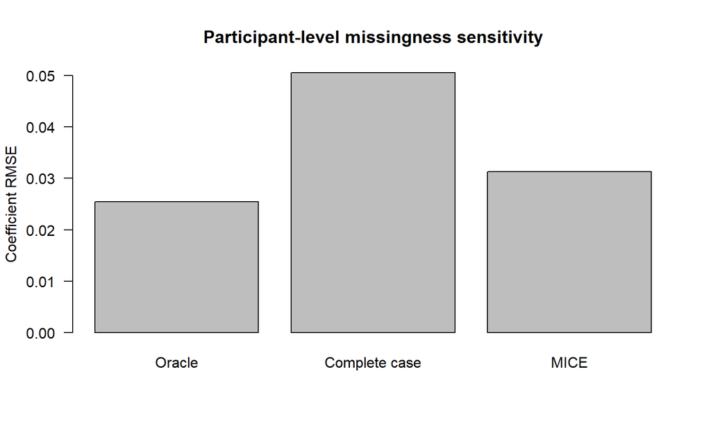

Coefficient RMSE in the 200-outcome participant-level MCAR sensitivity analysis. Lower is better for this particular design.

```r
barplot(
  height = mice_200$RMSE_beta,
  names.arg = c("Oracle", "Complete case", "MICE"),
  ylab = "Coefficient RMSE",
  main = "Participant-level missingness sensitivity",
  las = 1
)
```

## Robustness to four missingness assignments

The research archive contains four different random selections of the 1,251 participants whose exposure is artificially missing. The comparison uses the **same first 50 simulated outcomes for each assignment**, not four independent samples of 1,787 participants. For assignments 2–4 the original code sets the missingness-assignment seeds to `20261700 + assignment_number`; the repeated outcome comparison was then saved in `Table_MICE_Four_Assignments.csv` and `Table_MICE_Paired_Comparisons.csv`.

The original assignment construction and result summarization are documented in the following excerpts.

**Original R source · 78.RLines 475–533**

```
# STEP 74A
# THREE NEW PARTICIPANT-LEVEL MISSINGNESS ASSIGNMENTS
# ============================================================

library(dplyr)

make_new_assignment <- function(assignment_number) {

  set.seed(20261700L + assignment_number)

  missing_ids <- sample(
    mi_person_frame$SEQN,
    size = 1251L,
    replace = FALSE
  )

  # Build from original participant predictors.
  # Do not carry over the previous missingness indicator.

  design <- mi_person_frame %>%
    select(
      SEQN, cycle, Y, age_z, sex_binary,
      boundary_start, boundary_end,
      start_sin, start_cos
    ) %>%
    left_join(
      mi_pilot_truth %>%
        select(SEQN, cycle, X_true_z),
      by = c("SEQN", "cycle")
    ) %>%
    mutate(
      assignment = assignment_number,

      activity_missing = SEQN %in% missing_ids,

      X_observed_z = if_else(
        activity_missing,
        NA_real_,
        X_true_z
      )
    ) %>%
    select(-X_true_z)

  stopifnot(
    nrow(design) == 1787L,
    n_distinct(design$SEQN) == 1787L,

    sum(design$activity_missing) == 1251L,
    sum(!design$activity_missing) == 536L,

    sum(is.na(design$X_observed_z)) == 1251L,
    all(is.finite(
      design$X_observed_z[!design$activity_missing]
    )),

    !("X_true_z" %in% names(design))
  )

  design
```

**Original R source · 80.RLines 137–163**

```
# STEP 78
# PERFORMANCE BY MISSINGNESS ASSIGNMENT
# ============================================================

assignment_50_summary <- all_assignment_50_results %>%
  group_by(assignment, method) %>%
  summarise(
    outcomes = n(),

    mean_beta = mean(beta_hat),

    bias = mean(beta_hat) - 0.5,

    empirical_SD = sd(beta_hat),

    mean_model_SE = mean(model_SE),

    SE_ratio = empirical_SD / mean_model_SE,

    coverage = mean(covers_truth),

    RMSE_beta = sqrt(mean((beta_hat - 0.5)^2)),

    .groups = "drop"
  ) %>%
  arrange(assignment, method)
```

```r
stopifnot(
  nrow(mice_assignments) == 12L,
  !anyDuplicated(mice_assignments[c("assignment", "method")]),
  setequal(mice_assignments$assignment, 1:4),
  setequal(mice_assignments$method, comparison_labels),
  all(mice_assignments$outcomes == 50L),
  all(is.finite(mice_assignments$mean_beta)),
  all(mice_assignments$coverage >= 0 & mice_assignments$coverage <= 1),
  nrow(mice_paired) == 4L,
  setequal(mice_paired$assignment, 1:4),
  all(mice_paired$outcomes == 50L),
  all(mice_paired$mice_closer_percent >= 0 &
      mice_paired$mice_closer_percent <= 100),
  all(mice_paired$mean_absolute_error_mice <
      mice_paired$mean_absolute_error_cc)
)

first_match <- merge(mice_first50,
  mice_assignments[mice_assignments$assignment == 1L, ],
  by = "method", suffixes = c(".first50", ".assignment"))
stopifnot(
  nrow(first_match) == 3L,
  all(abs(first_match$mean_beta.first50 -
          first_match$mean_beta.assignment) < 1e-10),
  all(abs(first_match$coverage.first50 -
          first_match$coverage.assignment) < 1e-10)
)

assignment_view <- mice_assignments[mice_assignments$method == "Participant-level MICE", ]
assignment_view <- assignment_view[order(assignment_view$assignment), ]
knitr::kable(data.frame(
  Assignment = assignment_view$assignment,
  `Mean coefficient` = sprintf("%.4f", assignment_view$mean_beta),
  `Bias` = sprintf("%+.4f", assignment_view$bias),
  `Mean model SE` = sprintf("%.4f", assignment_view$mean_model_SE),
  `SE ratio` = sprintf("%.3f", assignment_view$SE_ratio),
  `95% CI coverage` = sprintf("%.0f%%", 100 * assignment_view$coverage),
  check.names = FALSE
), caption = "Outcome-aware participant-level MICE across four MCAR missingness assignments, each evaluated on the same 50 simulated outcomes.")
```

Outcome-aware participant-level MICE across four MCAR missingness assignments, each evaluated on the same 50 simulated outcomes.

| Assignment | Mean coefficient | Bias | Mean model SE | SE ratio | 95% CI coverage |
| --- | --- | --- | --- | --- | --- |
| 1 | 0.4976 | -0.0024 | 0.0303 | 1.012 | 96% |
| 2 | 0.5029 | +0.0029 | 0.0304 | 0.947 | 94% |
| 3 | 0.5062 | +0.0062 | 0.0299 | 1.113 | 94% |
| 4 | 0.5059 | +0.0059 | 0.0307 | 1.040 | 92% |

In the paired comparison, the metric **MICE closer (%)** is the percentage of the 50 matched outcome realizations in which the MICE activity coefficient has smaller absolute error than the complete-case coefficient. This does not constitute a formal test of superiority across independent population samples.

```r
mice_paired <- mice_paired[order(mice_paired$assignment), ]
knitr::kable(data.frame(
  Assignment = mice_paired$assignment,
  `CC mean absolute error` = sprintf("%.4f", mice_paired$mean_absolute_error_cc),
  `MICE mean absolute error` = sprintf("%.4f", mice_paired$mean_absolute_error_mice),
  `MICE closer` = sprintf("%.0f%%", mice_paired$mice_closer_percent),
  `CC coverage` = sprintf("%.0f%%", 100 * mice_paired$coverage_cc),
  `MICE coverage` = sprintf("%.0f%%", 100 * mice_paired$coverage_mice),
  check.names = FALSE
), caption = "Paired complete-case and MICE comparisons using the original archived matched outcomes.")
```

Paired complete-case and MICE comparisons using the original archived matched outcomes.

| Assignment | CC mean absolute error | MICE mean absolute error | MICE closer | CC coverage | MICE coverage |
| --- | --- | --- | --- | --- | --- |
| 1 | 0.0399 | 0.0257 | 70% | 94% | 96% |
| 2 | 0.0405 | 0.0230 | 66% | 94% | 94% |
| 3 | 0.0393 | 0.0273 | 70% | 96% | 94% |
| 4 | 0.0429 | 0.0246 | 74% | 88% | 92% |

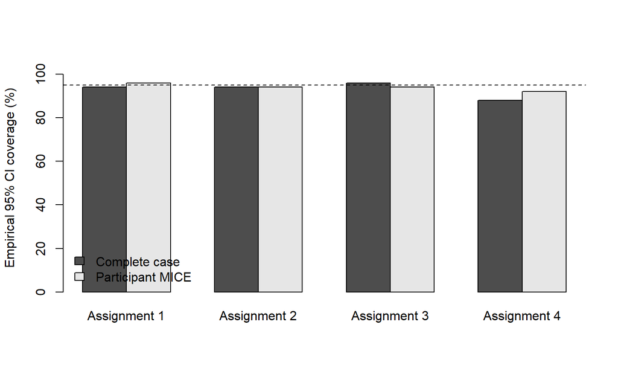

Empirical 95% confidence interval coverage across the four matched-outcome missingness assignments. Each bar reflects 50 outcomes, and coverage estimates have Monte Carlo uncertainty.

```r
cover_mat <- rbind(
  `Complete case` = mice_paired$coverage_cc * 100,
  `Participant MICE` = mice_paired$coverage_mice * 100
)
barplot(cover_mat, beside = TRUE,
        names.arg = paste("Assignment", mice_paired$assignment),
        ylab = "Empirical 95% CI coverage (%)", ylim = c(0, 105))
abline(h = 95, lty = 2)
legend("bottomleft", legend = rownames(cover_mat), fill = gray.colors(2), bty = "n")
```

## MICE checkpoint verification

All 200 individual outcome checkpoints from the first assignment, the 150 outcome checkpoints from assignments 2–4, and the final CSV summary files remain in the original research archive. We verify their presence and uniqueness without rerunning `mice()`.

```r
first_assignment_checkpoints <- file.path(
  mice_dir, sprintf("participant_mi_outcome_%02d.rds", 1:200)
)
# Original script uses %02d: indices 100--200 appear as three digits.
other_assignment_checkpoints <- unlist(lapply(2:4, function(a) {
  file.path(mice_dir, sprintf(
    "participant_assignment_%02d_outcome_%03d.rds", a, 1:50))
}), use.names = FALSE)
stopifnot(
  length(first_assignment_checkpoints) == 200L,
  length(other_assignment_checkpoints) == 150L,
  all(file.exists(first_assignment_checkpoints)),
  all(file.exists(other_assignment_checkpoints)),
  !anyDuplicated(c(first_assignment_checkpoints, other_assignment_checkpoints))
)
cat("PASS: 200 first-assignment and 150 additional-assignment outcome ",
    "checkpoints located; summary tables verified without new MICE fits.", sep = "")
```

```
## PASS: 200 first-assignment and 150 additional-assignment outcome checkpoints located; summary tables verified without new MICE fits.
```

```r
mice_input_audit <- data.frame(
  `Archived input` = names(mice_files),
  `Relative path` = unname(mice_files),
  `MD5` = unname(tools::md5sum(mice_files)),
  check.names = FALSE
)
knitr::kable(mice_input_audit, caption = "Original saved MICE CSV inputs and file checksums.")
```

Original saved MICE CSV inputs and file checksums.

| Archived input | Relative path | MD5 |
| --- | --- | --- |
| summary_200 | R results/Final 2011-2014/Inference/Repeated masking/Outcome simulations/Outcome aware MICE/participant_mice_200outcome_summary.csv | 8165f0eebd54ce303ddbee1e884d3024 |
| saved_table_200 | R results/Final 2011-2014/Inference/Repeated masking/Outcome simulations/Outcome aware MICE/Table_MICE_200_Outcomes.csv | 8165f0eebd54ce303ddbee1e884d3024 |
| assignment_summary | R results/Final 2011-2014/Inference/Repeated masking/Outcome simulations/Outcome aware MICE/Table_MICE_Four_Assignments.csv | e0d5ac58d1b92e9e84c7336ba7310e46 |
| paired_summary | R results/Final 2011-2014/Inference/Repeated masking/Outcome simulations/Outcome aware MICE/Table_MICE_Paired_Comparisons.csv | ff28e634df95993d8ec32aedaeb0d83d |
| first_50 | R results/Final 2011-2014/Inference/Repeated masking/Outcome simulations/Outcome aware MICE/participant_mice_50outcome_summary.csv | c8a098b268069c228f60491d000c88f3 |

The saved outputs provide a reproducible **results-regeneration pathway** for this experiment. Fully replicating MICE from the source participant-level data additionally requires executing the original data preparation and repeated-imputation code in an appropriate R environment. The favorable MICE results are conditional on the participant-level MCAR design, the inclusion of the simulated outcome in the imputation model, and the algorithm settings above.

# Observed BMI application

The earlier analyses evaluated known regression parameters using **simulated outcomes**. This section presents a separate **observed-outcome illustration**: the association between reconstructed wrist-worn activity and recorded body mass index (BMI, `BMXBMI`). It uses the original **NHANES 2013–2014 (`H`) cycle**, not the combined-cycle cohort used in the primary simulation. The archived files were generated by the earlier BMI workflow in scripts `33.R`–`38.R`. The website loads the original saved results without fitting survey models, repeating imputation, or modifying any files.

**Important interpretation:** In this observational analysis the activity coefficient is **not known**. The coefficient from the original complete eight-hour activity window is used as a **within-mask reference estimate**, not as a true causal effect or an error-free population parameter. Consequently, the differences below measure *changes in the fitted association when exposures are reconstructed*, not simulation bias against a known parameter. Survey weights were applied within this selected cohort; selection into a complete-window cohort is not corrected by simply adding those weights, and the analysis should not be called nationally representative.

## Analytic cohort and regression specification

The BMI analysis begins from an earlier pool of 2,117 participants with eligible complete eight-hour windows in the 2013–2014 data. The final cohort contains **961 adults**, defined in the original `34.R` by age at least 20 years, observed BMI, positive Medical Examination Center (MEC) weight (`WTMEC2YR`), observed survey PSU and stratum indicators, and exclusion of women recorded as pregnant. The same 961 adults contribute to the 20 repeated activity-window selections. These are **not 20 independent samples of people**.

**Original R source · 34.RLines 1–41**

```
# ============================================================
# CORRECT ADULT BMI ANALYTIC COHORT
# ============================================================

real_bmi_adults <- real_bmi_base %>%
  mutate(

    # TRUE only when NHANES actually identifies the woman
    # as pregnant.
    known_pregnant =
      coalesce(
        RIAGENDR == 2 &
          RIDEXPRG == 1,
        FALSE
      )

  ) %>%

  filter(

    # Adults
    !is.na(RIDAGEYR),
    RIDAGEYR >= 20,

    # Observed BMI
    !is.na(BMXBMI),

    # Valid MEC examination weight
    !is.na(WTMEC2YR),
    WTMEC2YR > 0,

    # Survey design variables
    !is.na(SDMVPSU),
    !is.na(SDMVSTRA),

    # Exclude only women KNOWN to be pregnant
    !known_pregnant
  )


# ============================================================
```

The reference and reconstructed-exposure analyses use `survey::svydesign(ids = ~SDMVPSU, strata = ~SDMVSTRA, weights = ~WTMEC2YR, nest = TRUE)` and fit a survey-weighted model of the form

$$\operatorname{BMI}_i = \alpha + \theta X_{i,z} +
\gamma\,\operatorname{Age}_{i,z}
+ \delta\,\operatorname{Sex}_i + \boldsymbol{\eta}^{\mathsf
T}\operatorname{RaceEthnicity}_i + e_i.$$

Here $X_{i,z}$ is the selected window’s **standardized eight-hour mean MIMS activity**, with all reconstructed exposures placed on the corresponding reference-exposure scale for that window selection. The design-based coefficients and standard errors are obtained using `survey::svyglm()`. There is no synthetic $\beta=0.5$ target in this section.

**Original R source · 36.RLines 63–105**

```
  # NHANES survey design
  # ----------------------------------------------------------

  design <- survey::svydesign(
    ids =
      ~ SDMVPSU,

    strata =
      ~ SDMVSTRA,

    weights =
      ~ WTMEC2YR,

    nest =
      TRUE,

    data =
      analysis_dat
  )


  # ----------------------------------------------------------
  # Regression formula
  # ----------------------------------------------------------

  model_formula <- reformulate(
    termlabels = c(
      exposure_variable,
      "age_z",
      "sex",
      "race_ethnicity"
    ),

    response =
      "BMXBMI"
  )


  fit <- survey::svyglm(
    model_formula,
    design = design
  )
```

## Original 20-mask BMI experiment and imputation methods

For each of 20 activity-window selections (`20261200 + r`, where $r$ is the selection number), the original code compares regression using the complete reference exposure with regression after hourly reconstruction using linear interpolation, hierarchical time-of-day means, kNN ($k=5$), and random forest. In **this earlier BMI application** the forest is fitted with **100 trees**, not the 200 trees used in the later combined-cycle primary study. The observed health outcome does not enter the four single-reconstruction methods.

**Original R source · 35.RLines 39–120**

```
    group_by(SEQN) %>%
    summarise(
      true_activity =
        mean(PAXMTSH),

      .groups = "drop"
    )


  # ----------------------------------------------------------
  # 3. Restrict reference exposure to the 961 adults
  # ----------------------------------------------------------

  adult_true <- real_bmi_adults %>%
    select(
      SEQN,
      BMXBMI,
      RIDAGEYR,
      RIAGENDR,
      RIDRETH3,
      WTMEC2YR,
      SDMVPSU,
      SDMVSTRA
    ) %>%
    inner_join(
      true_window_rep,
      by = "SEQN"
    )


  if (nrow(adult_true) != 961) {

    stop(
      paste0(
        "Expected 961 adults but found ",
        nrow(adult_true),
        "."
      )
    )
  }
```

[output cut: 26 more lines]

```
        true_sd,

      sex =
        RIAGENDR - 1,

      age_z =
        as.numeric(
          scale(RIDAGEYR)
        )
    )


  # ----------------------------------------------------------
  # 5. LINEAR
  # ----------------------------------------------------------
```

**Original R source · 36.RLines 304–380**

```
  bmi_data_r <- build_real_bmi_exposures_one_mask(
    mask_replicate = r,
    mask_seed = 20261200 + r
  )


  # ----------------------------------------------------------
  # 2. Reference model for THIS mask
  # ----------------------------------------------------------

  reference_r <- fit_bmi_survey_model(
    dat =
      bmi_data_r$adult_true,

    exposure_variable =
      "activity_z",

    method_name =
      "Reference: true activity",

    gap_label =
      "No missingness"
  )


  # ----------------------------------------------------------
  # 3. Four imputation methods
  # ----------------------------------------------------------

  imputed_r <- bmi_data_r$imputed_adults %>%
    group_by(
      method,
      gap
    ) %>%
    group_split() %>%
    purrr::map_dfr(
      function(dat) {

        fit_bmi_survey_model(
          dat =
            dat,

          exposure_variable =
            "activity_imputed_z",

          method_name =
            first(dat$method),

          gap_label =
            first(dat$gap)
        )
      }
    )


  # ----------------------------------------------------------
  # 4. Compare every imputed estimate with THIS MASK'S
  #    true/reference estimate
  # ----------------------------------------------------------

  result_r <- bind_rows(
    reference_r,
    imputed_r
  ) %>%
    mutate(
      mask_replicate =
        r,

      reference_beta =
        reference_r$beta_hat,

      beta_difference =
        beta_hat -
        reference_r$beta_hat,

      absolute_beta_difference =
        abs(
```

The archive also contains a **fifth method, outcome-aware MICE-PMM with BMI**. Unlike the preceding participant-level MICE sensitivity analysis, this procedure imputes the **artificially missing hourly MIMS values**, includes observed BMI and race/ethnicity among its predictors, uses 20 imputations with five PMM donors, and combines survey-weighted regression coefficients using Rubin’s rules. The original implementation used `maxit = 1` and a complete-data residual degrees-of-freedom value of 7 for pooling. Those settings are documented here rather than silently treated as general recommendations. This is a separate analysis and should not be pooled with the earlier participant-level MCAR experiment.

**Original R source · 37.RLines 378–434**

```
  method[] <- ""

  method["MIMS"] <-
    "pmm"


  predictor_matrix <-
    mice::make.predictorMatrix(
      mice_data
    )

  predictor_matrix[,] <- 0


  # Missing MIMS is predicted using:
  #
  # - wearable/time/context predictors
  # - actual BMI outcome
  # - race/ethnicity
  #
  # Age and sex are already contained in ml_feature_names.
  predictor_matrix[
    "MIMS",
    c(
      ml_feature_names,
      "BMXBMI",
      "race_ethnicity"
    )
  ] <- 1


  # ----------------------------------------------------------
  # 5. Generate 20 imputations
  # ----------------------------------------------------------

  mice_fit <- mice::mice(
    data =
      mice_data,

    m =
      m,

    maxit =
      1,

    method =
      method,

    predictorMatrix =
      predictor_matrix,

    donors =
      pmm_donors,

    seed =
      seed,
```

**Original R source · 37.RLines 656–683**

```
  # ----------------------------------------------------------
  # 12. Rubin pooling using the survey complete-data df = 7
  # ----------------------------------------------------------

  pooled <- pool_scalar_survey_df(
    Q =
      model_results$beta_hat,

    U =
      model_results$SE^2,

    dfcom =
      dfcom
  )


  pooled_beta <-
    pooled$qbar

  pooled_SE <-
    pooled$SE

  pooled_df <-
    pooled$df


  critical_value <-
    qt(
```

## Archived BMI estimates and internal consistency

The four single-imputation methods produce 20 reference rows and $20\times4\times3 = 240$ method–gap rows. Outcome-aware MICE produces a further $20\times3=60$ rows. We check the saved results at the *individual window-selection level*, rather than merely displaying manually copied averages.

```r
bmi_dir <- file.path("R results", "Real BMI application")
bmi_files <- c(
  four_details = file.path(bmi_dir, "real_bmi_results_all_four_methods.csv"),
  four_summary = file.path(bmi_dir, "real_bmi_distortion_summary_four_methods.csv"),
  mice_details = file.path(bmi_dir, "real_bmi_mice_results_all.csv"),
  mice_summary = file.path(bmi_dir, "real_bmi_mice_distortion_summary.csv"),
  combined_summary = file.path(bmi_dir, "final_five_method_real_bmi_summary.csv")
)
if (!all(file.exists(bmi_files))) {
  stop("Missing original real BMI file(s): ",
       paste(bmi_files[!file.exists(bmi_files)], collapse = ", "))
}
bmi_four <- read.csv(bmi_files[["four_details"]], check.names = FALSE)
bmi_four_summary <- read.csv(bmi_files[["four_summary"]], check.names = FALSE)
bmi_mice <- read.csv(bmi_files[["mice_details"]], check.names = FALSE)
bmi_mice_summary <- read.csv(bmi_files[["mice_summary"]], check.names = FALSE)
bmi_combined <- read.csv(bmi_files[["combined_summary"]], check.names = FALSE)

bmi_methods <- c("Linear interpolation", "Time-of-day mean",
                 "kNN (k = 5)", "Random forest", "MICE-PMM + BMI")
bmi_gaps <- c("1 hour", "3 hours", "6 hours")
stopifnot(
  nrow(bmi_four) == 260L,
  nrow(bmi_mice) == 60L,
  nrow(bmi_four_summary) == 12L,
  nrow(bmi_mice_summary) == 3L,
  nrow(bmi_combined) == 15L,
  all(bmi_four$n == 961L),
  all(bmi_mice$n == 961L),
  setequal(bmi_four$mask_replicate, 1:20),
  setequal(bmi_mice$mask_replicate, 1:20),
  sum(bmi_four$method == "Reference: true activity") == 20L,
  all(table(bmi_four$mask_replicate) == 13L),
  all(table(bmi_mice$mask_replicate) == 3L),
  all(bmi_mice$imputations == 20L),
  !anyDuplicated(bmi_combined[c("gap", "method")]),
  setequal(bmi_combined$method, bmi_methods),
  setequal(bmi_combined$gap, bmi_gaps),
  all(bmi_combined$masks == 20L),
  all(is.finite(bmi_combined$mean_beta_difference)),
  all(is.finite(bmi_combined$mean_absolute_difference))
)
# Match the reference fitted coefficient within each window selection.
bmi_reference <- bmi_four[
  bmi_four$method == "Reference: true activity",
  c("mask_replicate", "beta_hat")
]
stopifnot(!anyDuplicated(bmi_reference$mask_replicate))
for (dat in list(bmi_four, bmi_mice)) {
  reference_for_row <- bmi_reference$beta_hat[
    match(dat$mask_replicate, bmi_reference$mask_replicate)
  ]
  stopifnot(
    !anyNA(reference_for_row),
    max(abs(dat$reference_beta - reference_for_row)) < 1e-10,
    max(abs(dat$beta_difference - (dat$beta_hat - reference_for_row))) < 1e-10,
    max(abs(dat$absolute_beta_difference - abs(dat$beta_difference))) < 1e-10
  )
}
# Ensure the five-method summary agrees with all the individual-mask estimates.
bmi_all_methods <- rbind(
  bmi_four[bmi_four$method != "Reference: true activity",
           c("method", "gap", "beta_difference", "absolute_beta_difference")],
  bmi_mice[, c("method", "gap", "beta_difference", "absolute_beta_difference")]
)
bmi_recalculated <- aggregate(
  cbind(beta_difference, absolute_beta_difference) ~ method + gap,
  data = bmi_all_methods, FUN = mean
)
bmi_recheck <- merge(bmi_combined, bmi_recalculated,
                     by = c("method", "gap"), suffixes = c(".saved", ".computed"))
stopifnot(
  nrow(bmi_recheck) == 15L,
  max(abs(bmi_recheck$mean_beta_difference - bmi_recheck$beta_difference)) < 1e-10,
  max(abs(bmi_recheck$mean_absolute_difference - bmi_recheck$absolute_beta_difference)) < 1e-10
)
cat("PASS: 260 saved reference/single-reconstruction records, 60 saved BMI-MICE records, and all 15 five-method summary rows validated. No regressions or imputations rerun.")
```

```
## PASS: 260 saved reference/single-reconstruction records, 60 saved BMI-MICE records, and all 15 five-method summary rows validated. No regressions or imputations rerun.
```

## Changes in the observed BMI–activity association

For each selection $r$, define the *reference* survey-weighted coefficient $\widehat\theta_{r,\mathrm{ref}}$ and the fitted coefficient using method $m$ and gap length $g$, $\widehat\theta_{r,m,g}$. The reported coefficient difference is

$$\Delta_{r,m,g}=\widehat\theta_{r,m,g}-\widehat\theta_{r,\mathrm{ref}}.$$

The mean difference and mean absolute difference summarize, across the 20 repeated selections, how each reconstruction procedure changes the *observed* BMI association. They are **not** estimates of statistical bias relative to an unknown true health-effect parameter.

```r
bmi_combined <- bmi_combined[
  order(match(bmi_combined$gap, bmi_gaps),
        match(bmi_combined$method, bmi_methods)), ]
knitr::kable(data.frame(
  `Missing block` = bmi_combined$gap,
  Method = bmi_combined$method,
  `Mean reference coefficient` = sprintf("%+.4f", bmi_combined$mean_reference_beta),
  `Mean reconstructed coefficient` = sprintf("%+.4f", bmi_combined$mean_imputed_beta),
  `Mean coefficient shift` = sprintf("%+.4f", bmi_combined$mean_beta_difference),
  `Mean absolute shift` = sprintf("%.4f", bmi_combined$mean_absolute_difference),
  `Mean model SE` = sprintf("%.4f", bmi_combined$mean_SE),
  check.names = FALSE
), caption = "Observed BMI application: activity-coefficient changes relative to each mask's complete-window reference regression (961 adults, 20 window selections per method-gap combination).")
```

Observed BMI application: activity-coefficient changes relative to each mask’s complete-window reference regression (961 adults, 20 window selections per method-gap combination).

| Missing block | Method | Mean reference coefficient | Mean reconstructed coefficient | Mean coefficient shift | Mean absolute shift | Mean model SE |
| --- | --- | --- | --- | --- | --- | --- |
| 1 hour | Linear interpolation | -0.4961 | -0.4955 | +0.0006 | 0.0137 | 0.2397 |
| 1 hour | Time-of-day mean | -0.4961 | -0.5253 | -0.0292 | 0.0301 | 0.2479 |
| 1 hour | kNN (k = 5) | -0.4961 | -0.4958 | +0.0003 | 0.0131 | 0.2378 |
| 1 hour | Random forest | -0.4961 | -0.4977 | -0.0016 | 0.0125 | 0.2387 |
| 1 hour | MICE-PMM + BMI | -0.4961 | -0.5028 | -0.0067 | 0.0149 | 0.2505 |
| 3 hours | Linear interpolation | -0.4961 | -0.5156 | -0.0195 | 0.0352 | 0.2520 |
| 3 hours | Time-of-day mean | -0.4961 | -0.5946 | -0.0985 | 0.0985 | 0.2939 |
| 3 hours | kNN (k = 5) | -0.4961 | -0.5549 | -0.0588 | 0.0588 | 0.2570 |
| 3 hours | Random forest | -0.4961 | -0.5771 | -0.0811 | 0.0811 | 0.2755 |
| 3 hours | MICE-PMM + BMI | -0.4961 | -0.5467 | -0.0506 | 0.0531 | 0.2833 |
| 6 hours | Linear interpolation | -0.4961 | -0.5153 | -0.0192 | 0.0459 | 0.2839 |
| 6 hours | Time-of-day mean | -0.4961 | -0.7314 | -0.2353 | 0.2353 | 0.3824 |
| 6 hours | kNN (k = 5) | -0.4961 | -0.7291 | -0.2330 | 0.2330 | 0.3439 |
| 6 hours | Random forest | -0.4961 | -0.7580 | -0.2619 | 0.2619 | 0.4052 |
| 6 hours | MICE-PMM + BMI | -0.4961 | -0.5616 | -0.0655 | 0.0705 | 0.3358 |

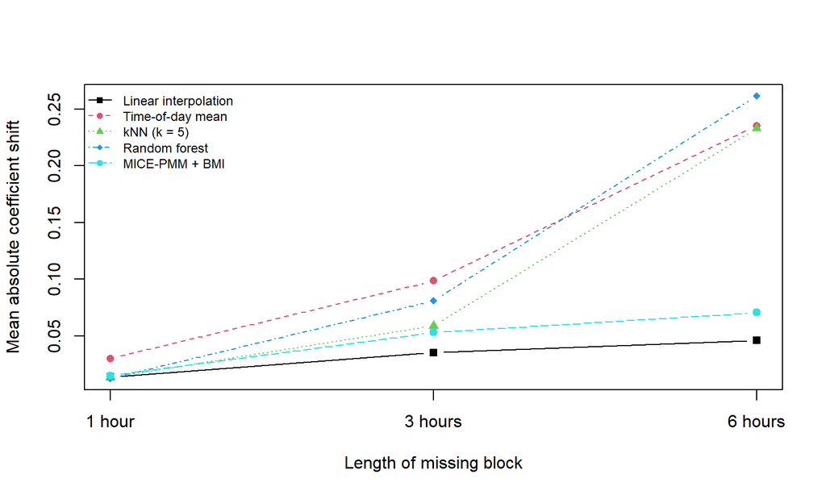

Mean absolute difference between reconstructed-exposure and reference survey-weighted BMI regression coefficients, by gap length (20 selections per setting).

```r
shift_matrix <- xtabs(mean_absolute_difference ~ method + gap,
                      data = bmi_combined)
shift_matrix <- shift_matrix[bmi_methods, bmi_gaps, drop = FALSE]
matplot(1:3, t(shift_matrix), type = "b", pch = 15:19,
        lty = 1:5, col = 1:5, xaxt = "n",
        xlab = "Length of missing block", ylab = "Mean absolute coefficient shift")
axis(1, at = 1:3, labels = bmi_gaps)
legend("topleft", legend = rownames(shift_matrix), pch = 15:19,
       col = 1:5, lty = 1:5, cex = .76, bty = "n")
```

In the archived BMI analysis, the mean complete-window reference coefficient was approximately -0.496 across repeated selections. This describes a **negative conditional association**, not a causal effect. For six-hour gaps, mean activity-coefficient shifts relative to the corresponding reference estimates were approximately -0.262 for random forest and -0.065 for BMI-aware MICE. This observational comparison illustrates that the fitted coefficient can change substantially when activity measurements are reconstructed. **It does not establish which method identifies a true causal association.**

## Interpretation and limitations

This BMI application is informative because the outcome is **observed**, but it has its own methodological limitations. It uses the earlier single-cycle cohort of 961 adults, not the final 3,635-person combined-cycle cohort; its random forest uses 100 trees rather than 200; and the fifth method performs **BMI-aware imputation of hourly activity measurements**, not the separately evaluated participant-level MCAR exposure imputation. In addition, repeated windows for the same adults are not independent population replications. A proportion of regression $p$-values below 0.05 across those windows would be a *selection-sensitivity descriptive measure*, **not** a simulated Type I error rate or coverage probability. The survey-weighted analysis on this selected sample is not automatically nationally representative.

The website therefore reports coefficient changes relative to complete-window reference fits, without treating these changes as differences from a known causal parameter or as a randomized comparison among imputation methods.

## BMI result-file provenance and source scripts

```r
bmi_audit <- data.frame(
  Source = names(bmi_files),
  `Original relative path` = unname(bmi_files),
  `MD5 checksum` = unname(tools::md5sum(bmi_files)),
  check.names = FALSE
)
knitr::kable(bmi_audit,
  caption = "Checksums and unchanged original CSV file paths for the observed BMI application.")
```

Checksums and unchanged original CSV file paths for the observed BMI application.

| Source | Original relative path | MD5 checksum |
| --- | --- | --- |
| four_details | R results/Real BMI application/real_bmi_results_all_four_methods.csv | 8f3dbf737d3d76689852b6ed156e5555 |
| four_summary | R results/Real BMI application/real_bmi_distortion_summary_four_methods.csv | 00766d4b3be616de37457ccda70cc6f0 |
| mice_details | R results/Real BMI application/real_bmi_mice_results_all.csv | 83a783797fdfbe067357a2d1e1a7b026 |
| mice_summary | R results/Real BMI application/real_bmi_mice_distortion_summary.csv | e36a86329a068b3c68c91d116bf916f8 |
| combined_summary | R results/Real BMI application/final_five_method_real_bmi_summary.csv | 5f176ff9f09af5bd49e19c12b46066a8 |

```r
bmi_checkpoint_paths <- file.path(bmi_dir,
  sprintf("real_bmi_mask_%02d.rds", 1:20))
bmi_mice_checkpoint_paths <- file.path(bmi_dir,
  sprintf("real_bmi_mice_mask_%02d.rds", 1:20))
stopifnot(
  all(file.exists(bmi_checkpoint_paths)),
  all(file.exists(bmi_mice_checkpoint_paths))
)
cat("PASS: all 20 saved original-method BMI checkpoints and 20 BMI-MICE checkpoints are present.")
```

```
## PASS: all 20 saved original-method BMI checkpoints and 20 BMI-MICE checkpoints are present.
```

The documented lineage is `33.R` (single-cycle BMI inputs), `34.R` (corrected adult eligibility), `35.R` (complete and reconstructed eight-hour exposures), `36.R` (survey-weighted regression and 20 masked windows), `37.R` (outcome-aware hourly PMM and survey pooling), and `38.R` (20-mask MICE analysis and combined summary). The original scripts may rely on objects created in earlier R sessions; this chapter verifies **archived outputs** and does not claim a clean-session rerun of the entire BMI workflow.

# Discussion and limitations

The results demonstrate that optimizing pointwise reconstruction error does not, by itself, ensure valid downstream regression inference. Across the studied artificial gap lengths, random forest achieved the smallest hourly reconstruction RMSE, but kNN was markedly better calibrated for the regression coefficient under the longest gap. The Frisch–Waugh–Lovell projection links these outcomes to changes in the covariate-adjusted covariance and variance of the reconstructed activity exposure.

Inference is conditional on the selected NHANES reference windows, fixed within-window gap positions, chosen reconstruction implementations, and the stated linear outcome-generating mechanism. The recorded hourly MIMS sums are a **reference measurement**, not an error-free measure of latent physical activity. The primary simulations did not apply NHANES sampling weights and should not be interpreted as nationally representative estimates.

The fixed-mask $\beta=0$ experiment, participant-level MCAR/MICE experiment, and observational BMI application have deliberately different cohorts, missingness mechanisms, and objectives. Their findings extend the scope of this report but are not pooled as if arising from the same simulation design. The observed BMI coefficients describe associations and their sensitivity to reconstruction; they do not identify causal effects or measure bias relative to an unknown population coefficient.

# Source-code provenance

The original NHANES inputs, intermediate RDS checkpoints, and 81 numbered R scripts have been retained in the research archive. The public report provides **archived-result traceability**, rather than claiming a new clean-session execution of all upstream analyses. The following inventory identifies the generating scripts for the reported results.

```r
script_map <- data.frame(
  `Original script` = c("40.R", "41.R", "43.R", "64.R", "70.R", "71.R", "72.R", "81.R", "62.R", "77.R", "78.R", "79.R", "80.R", "33.R", "34.R", "35.R", "36.R", "37.R", "38.R"),
  `Saved analysis/output` = c(
    "Combine the two NHANES cycles",
    "Combined-cycle cleaning, valid days, clean hours, header time",
    "Final eight-hour clean-window detector",
    "20 replicated reference-window selections and reference exposures",
    "20-mask primary reconstruction summary",
    "FWL regression simulation function and numerical cross-checks",
    "Primary outcome simulation and theory alignment summaries",
    "Manuscript Tables 1 and 2",
    "Fixed-mask beta=0 Type I error summary (separate design)",
    "Participant-level outcome-aware PMM specification, 20 imputations and 200 outcomes",
    "Participant alignment, Monte Carlo audit and missingness assignment generation",
    "Additional assignment per-outcome checkpoint generator",
    "MICE outcomes across four MCAR assignments and paired comparisons",
    "BMI single-cycle reference cohort and initial linkage",
    "Corrected adult eligibility and exclusions",
    "BMI complete-window and reconstructed exposure construction",
    "Survey-weighted BMI regression for 20 window selections",
    "BMI-aware hourly MICE and survey pooling",
    "Real BMI application summary"
  ),
  check.names = FALSE
)
knitr::kable(script_map, caption = "Original scripts that write relevant saved outputs.")
```

Original scripts that write relevant saved outputs.

| Original script | Saved analysis/output |
| --- | --- |
| 40.R | Combine the two NHANES cycles |
| 41.R | Combined-cycle cleaning, valid days, clean hours, header time |
| 43.R | Final eight-hour clean-window detector |
| 64.R | 20 replicated reference-window selections and reference exposures |
| 70.R | 20-mask primary reconstruction summary |
| 71.R | FWL regression simulation function and numerical cross-checks |
| 72.R | Primary outcome simulation and theory alignment summaries |
| 81.R | Manuscript Tables 1 and 2 |
| 62.R | Fixed-mask beta=0 Type I error summary (separate design) |
| 77.R | Participant-level outcome-aware PMM specification, 20 imputations and 200 outcomes |
| 78.R | Participant alignment, Monte Carlo audit and missingness assignment generation |
| 79.R | Additional assignment per-outcome checkpoint generator |
| 80.R | MICE outcomes across four MCAR assignments and paired comparisons |
| 33.R | BMI single-cycle reference cohort and initial linkage |
| 34.R | Corrected adult eligibility and exclusions |
| 35.R | BMI complete-window and reconstructed exposure construction |
| 36.R | Survey-weighted BMI regression for 20 window selections |
| 37.R | BMI-aware hourly MICE and survey pooling |
| 38.R | Real BMI application summary |

Original XPT inputs and intermediate participant-level checkpoints are not included in the public GitHub Pages release. The public repository contains the rendered report, source R Markdown, approved aggregate summaries, and a standalone verification script. The publicly distributed files support checks of the reported aggregate results but not a complete rerun of all imputation procedures.

# Reproducibility and verification

The verification evidence is reported at three levels: agreement of the displayed results with archived summaries, reproducibility from saved computational checkpoints, and execution of the entire data-processing and simulation pipeline from raw NHANES records. These are distinct levels of evidence and are not interchangeable.

| Level | What is currently documented | What remains necessary |
| --- | --- | --- |
| **Manuscript-results traceability** | Reported tables are linked to original archived CSV files and checked numerically against the manuscript. | Aggregate summary files and the standalone public verification script are included in the repository. |
| **Checkpoint reproducibility** | The original RDS files and the numbered generating scripts exist; this site verifies counts and selected table calculations. | Provide accessible checkpoints, suitable software versions, and code to regenerate all reported tables from them. |
| **Full computational reproduction** | Original raw NHANES XPT data and scripts 1–81 have been retained unchanged. | Build and test a clean-session driver, document package versions and execution time, and rerun as a separate verification exercise. |

## Primary result-file provenance

The relative paths and file checksums below make it possible to identify exactly which archived files were used to render the tables. Checksums are calculated locally on the input files, not entered manually.

```r
input_provenance <- data.frame(
  Input = names(required_files),
  `Original relative path` = unname(required_files),
  `MD5 of original CSV` = unname(tools::md5sum(required_files)),
  check.names = FALSE
)
knitr::kable(input_provenance, caption = "Source CSVs within the original research folder.")
```

Source CSVs within the original research folder.

| Input | Original relative path | MD5 of original CSV |
| --- | --- | --- |
| reconstruction | R results/Final 2011-2014/Inference/Repeated masking/all20_reconstruction_summary.csv | 51bb11ce62febc73cfac41433134ae46 |
| inference | R results/Final 2011-2014/Inference/Repeated masking/Outcome simulations/full_inference_summary.csv | 08cc4bd21a832a712093db544eb638a9 |
| table1 | R results/Final 2011-2014/Inference/Repeated masking/Outcome simulations/Manuscript tables/Table_1_Reconstruction.csv | eb9833af041cfa711505f0192fe534d1 |
| table2 | R results/Final 2011-2014/Inference/Repeated masking/Outcome simulations/Manuscript tables/Table_2_Inference.csv | a1667b84ae17d747e3e7640fd346f2a4 |
| theory | R results/Final 2011-2014/Inference/Repeated masking/Outcome simulations/theory_alignment_summary.csv | 979e3fdb23a6f300a4fb8d4f9e7db495 |

## Integrity inventory of the saved-analysis files

The following inventory documents the original *paths and checksums* used for the primary simulation, the null experiment, the participant-level MICE sensitivity analysis, and the BMI application. Checksums identify file bytes; they do not independently prove that the algorithms were correctly specified.

```r
release_aggregate_paths <- unique(c(
  unname(required_files),
  selection_csv,
  null_result_path,
  unname(mice_files),
  unname(bmi_files)
))
stopifnot(
  length(release_aggregate_paths) > 0,
  all(file.exists(release_aggregate_paths)),
  !anyDuplicated(release_aggregate_paths)
)
release_manifest <- data.frame(
  `Archived relative path` = release_aggregate_paths,
  `Size (bytes)` = as.numeric(file.info(release_aggregate_paths)$size),
  `MD5 checksum` = unname(tools::md5sum(release_aggregate_paths)),
  check.names = FALSE
)
knitr::kable(release_manifest,
  caption = "Aggregate-result provenance; all paths refer to the original research folder.")
```

Aggregate-result provenance; all paths refer to the original research folder.

| Archived relative path | Size (bytes) | MD5 checksum |
| --- | --- | --- |
| R results/Final 2011-2014/Inference/Repeated masking/all20_reconstruction_summary.csv | 2671 | 51bb11ce62febc73cfac41433134ae46 |
| R results/Final 2011-2014/Inference/Repeated masking/Outcome simulations/full_inference_summary.csv | 1816 | 08cc4bd21a832a712093db544eb638a9 |
| R results/Final 2011-2014/Inference/Repeated masking/Outcome simulations/Manuscript tables/Table_1_Reconstruction.csv | 663 | eb9833af041cfa711505f0192fe534d1 |
| R results/Final 2011-2014/Inference/Repeated masking/Outcome simulations/Manuscript tables/Table_2_Inference.csv | 961 | a1667b84ae17d747e3e7640fd346f2a4 |
| R results/Final 2011-2014/Inference/Repeated masking/Outcome simulations/theory_alignment_summary.csv | 1334 | 979e3fdb23a6f300a4fb8d4f9e7db495 |
| R results/Final 2011-2014/Inference/Repeated masking/selection_validation.csv | 149 | e28239750840fc5d9ecccfeb9556d28c |
| R results/Final 2011-2014/Inference/fixed_mask_beta0_type1_summary.csv | 1601 | 5fc4cb427e56af1675a93da2f746c1c5 |
| R results/Final 2011-2014/Inference/Repeated masking/Outcome simulations/Outcome aware MICE/participant_mice_200outcome_summary.csv | 595 | 8165f0eebd54ce303ddbee1e884d3024 |
| R results/Final 2011-2014/Inference/Repeated masking/Outcome simulations/Outcome aware MICE/Table_MICE_200_Outcomes.csv | 595 | 8165f0eebd54ce303ddbee1e884d3024 |
| R results/Final 2011-2014/Inference/Repeated masking/Outcome simulations/Outcome aware MICE/Table_MICE_Four_Assignments.csv | 1786 | e0d5ac58d1b92e9e84c7336ba7310e46 |
| R results/Final 2011-2014/Inference/Repeated masking/Outcome simulations/Outcome aware MICE/Table_MICE_Paired_Comparisons.csv | 565 | ff28e634df95993d8ec32aedaeb0d83d |
| R results/Final 2011-2014/Inference/Repeated masking/Outcome simulations/Outcome aware MICE/participant_mice_50outcome_summary.csv | 527 | c8a098b268069c228f60491d000c88f3 |
| R results/Real BMI application/real_bmi_results_all_four_methods.csv | 50158 | 8f3dbf737d3d76689852b6ed156e5555 |
| R results/Real BMI application/real_bmi_distortion_summary_four_methods.csv | 2537 | 00766d4b3be616de37457ccda70cc6f0 |
| R results/Real BMI application/real_bmi_mice_results_all.csv | 16598 | 83a783797fdfbe067357a2d1e1a7b026 |
| R results/Real BMI application/real_bmi_mice_distortion_summary.csv | 922 | e36a86329a068b3c68c91d116bf916f8 |
| R results/Real BMI application/final_five_method_real_bmi_summary.csv | 3377 | 5f176ff9f09af5bd49e19c12b46066a8 |

## Computational environment for this website

Package versions listed here describe **the current R installation used to render this page**, not necessarily the package versions used when each archived simulation checkpoint was originally created. Do not substitute them for a verified original lockfile.

```r
software_packages <- c("rmarkdown", "knitr", "dplyr", "tidyr", "FNN",
                       "ranger", "mice", "survey", "haven")
package_versions <- vapply(software_packages, function(p) {
  if (requireNamespace(p, quietly = TRUE))
    as.character(utils::packageVersion(p)) else "Not installed"
}, character(1))
knitr::kable(data.frame(
  Software = c("R", software_packages),
  `Version on this computer` = c(as.character(getRversion()),
                                 unname(package_versions)),
  check.names = FALSE
), caption = "Current rendering-environment versions (not verified historic simulation versions).")
```

Current rendering-environment versions (not verified historic simulation versions).

| Software | Version on this computer |
| --- | --- |
| R | 4.6.1 |
| rmarkdown | 2.32 |
| knitr | 1.52 |
| dplyr | 1.2.1 |
| tidyr | 1.3.2 |
| FNN | 1.1.4.1 |
| ranger | 0.18.0 |
| mice | 3.19.0 |
| survey | 4.5 |
| haven | 2.5.5 |

## Data, code and reproduction boundaries

The [public GitHub repository](https://github.com/adongo123/Wearable_Accelerometry_Imputation) contains the pre-rendered report (`index.html`), R Markdown source (`index.Rmd`), a standalone aggregate-results checker (`verify_public_results.R`), and approved summary CSV files. GitHub Pages serves the rendered HTML; **it does not execute R in a reader’s browser**. Using the public CSV files, the verification script performs 16 checks covering manuscript Tables 1 and 2 and supplementary aggregate summaries, including the null, MICE, and BMI analyses. These checks were completed successfully before publication of this report.

The local rendering pathway additionally validates selected original RDS checkpoints and file checksums. The public release excludes the NHANES XPT inputs, participant-level measurements, computational checkpoints, local RStudio files, and the unreviewed full set of numbered R scripts. Consequently, aggregate-result reproduction is available from the public files, whereas independently rerunning all original imputations and outcome simulations remains a separate computational task. The primary survey-cycle data are documented by [NHANES 2011–2012](https://wwwn.cdc.gov/Nchs/Data/Nhanes/Public/2011/DataFiles/PAXHR_G.htm) and [NHANES 2013–2014](https://wwwn.cdc.gov/Nchs/Data/Nhanes/Public/2013/DataFiles/PAXHR_H.htm).

```r
original_script_count <- sum(file.exists(script_paths))
checkpoints <- c(
  checkpoint_paths,
  first_assignment_checkpoints,
  other_assignment_checkpoints,
  bmi_checkpoint_paths,
  bmi_mice_checkpoint_paths
)
stopifnot(
  original_script_count == 81L,
  all(file.exists(checkpoints)),
  all(file.exists(release_aggregate_paths))
)
release_summary <- data.frame(
  Check = c("Original numbered R scripts",
            "Primary repeated-outcome checkpoints",
            "Participant-level MICE outcome checkpoints",
            "Observed BMI checkpoints",
            "Aggregate CSV inputs for public pre-rendered release"),
  Available = c(original_script_count, length(checkpoint_paths),
                length(first_assignment_checkpoints) + length(other_assignment_checkpoints),
                length(bmi_checkpoint_paths) + length(bmi_mice_checkpoint_paths),
                length(release_aggregate_paths)),
  check.names = FALSE
)
knitr::kable(release_summary,
             caption = "Local archive checks before constructing a public site release.")
```

Local archive checks before constructing a public site release.

| Check | Available |
| --- | --- |
| Original numbered R scripts | 81 |
| Primary repeated-outcome checkpoints | 20 |
| Participant-level MICE outcome checkpoints | 350 |
| Observed BMI checkpoints | 40 |
| Aggregate CSV inputs for public pre-rendered release | 17 |

```r
cat("PASS: public release preflight completed using existing files; no raw-data processing, imputation, or simulation was rerun.")
```

```
## PASS: public release preflight completed using existing files; no raw-data processing, imputation, or simulation was rerun.
```

The report provides **verification of archived aggregate results**, not independent full-pipeline replication, nationally representative activity estimates, or causal BMI-effect identification. All primary estimates retain the assumptions and population scope described in the study design and limitations sections.